# Mouses

## Used libraries. Please, check the versions of your libraries

```r
require(stringr) # version 1.4.0
require(readxl) # version 1.3.1
require(car) # version 3.0.10
require(ggplot2) # version 3.3.3
require(multcomp) # version 1.4.15
require(corrplot) # version 1.4.0
require(dplyr) # version 0.84
require(vegan) # version 2.5.7
require(RColorBrewer) # version 1.1.2
require(gridExtra) # version 2.3
```

In this research we trying to figure out how Down Syndrome in mice affect on the expression level of different proteins. Data was taken from article: [Ahmed MM, Dhanasekaran AR, Block A, Tong S, Costa AC, Stasko M, Gardiner KJ. Protein dynamics associated with failed and rescued learning in the Ts65Dn mouse model of Down syndrome. PLoS One. 2015 Mar 20;10(3):e0119491. doi: 10.1371/journal.pone.0119491. PMID: 25793384; PMCID: PMC4368539](https://doi.org/10.1371/journal.pone.0119491).

# 1. The description of the data

### Structure of the data

```r
url <- "https://archive.ics.uci.edu/ml/machine-learning-databases/00342/Data_Cortex_Nuclear.xls"
destfile <- "Data_Cortex_Nuclear.xls"
curl::curl_download(url, destfile)
data <- read_excel(destfile)
str(data)
```

```
## tibble [1,080 x 82] (S3: tbl_df/tbl/data.frame)
##  $ MouseID        : chr [1:1080] "309_1" "309_2" "309_3" "309_4" ...
##  $ DYRK1A_N       : num [1:1080] 0.504 0.515 0.509 0.442 0.435 ...
##  $ ITSN1_N        : num [1:1080] 0.747 0.689 0.73 0.617 0.617 ...
##  $ BDNF_N         : num [1:1080] 0.43 0.412 0.418 0.359 0.359 ...
##  $ NR1_N          : num [1:1080] 2.82 2.79 2.69 2.47 2.37 ...
##  $ NR2A_N         : num [1:1080] 5.99 5.69 5.62 4.98 4.72 ...
##  $ pAKT_N         : num [1:1080] 0.219 0.212 0.209 0.223 0.213 ...
##  $ pBRAF_N        : num [1:1080] 0.178 0.173 0.176 0.176 0.174 ...
##  $ pCAMKII_N      : num [1:1080] 2.37 2.29 2.28 2.15 2.13 ...
##  $ pCREB_N        : num [1:1080] 0.232 0.227 0.23 0.207 0.192 ...
##  $ pELK_N         : num [1:1080] 1.75 1.6 1.56 1.6 1.5 ...
##  $ pERK_N         : num [1:1080] 0.688 0.695 0.677 0.583 0.551 ...
##  $ pJNK_N         : num [1:1080] 0.306 0.299 0.291 0.297 0.287 ...
##  $ PKCA_N         : num [1:1080] 0.403 0.386 0.381 0.377 0.364 ...
```

[output cut: 68 more lines]

Vatiables *Genotype*, *Treatment* *Behavior* and *class* should be factors.

```r
data$Genotype <- as.factor(data$Genotype)
data$Treatment <- as.factor(data$Treatment)
data$Behavior <- as.factor(data$Behavior)
data$class <- as.factor(data$class)
```

### The amount of mouses in the experiment

The experiment involved `72` mice. Next table shows, that 15 measurements were registered of each protein per mice. The are `570` control measurements (`38` mice) and `510` trisomic measurements (`34` mice).

```r
table(str_remove(data$MouseID, pattern = '_.*'))
```

```
##
##  18899    293    294    309    311    320    321    322   3411   3412   3413
##     15     15     15     15     15     15     15     15     15     15     15
##   3414   3415   3416   3417   3418   3419   3420   3421   3422   3423   3424
##     15     15     15     15     15     15     15     15     15     15     15
##   3425   3426   3429   3476   3477   3478   3479   3480   3481   3483   3484
##     15     15     15     15     15     15     15     15     15     15     15
##   3488   3489   3490   3491   3497   3498   3499   3500   3501   3502   3503
##     15     15     15     15     15     15     15     15     15     15     15
##   3504   3505   3507   3513   3516   3517   3520   3521   3522   3525   3530
##     15     15     15     15     15     15     15     15     15     15     15
##   3534   3605   3606    361    362    363    364    365 50810A 50810B 50810C
##     15     15     15     15     15     15     15     15     15     15     15
## 50810D 50810E 50810F  J1291  J2292  J3295
##     15     15     15     15     15     15
```

### Group of measurements

In this experiment we can distinguish `8` groups:

- c-CS-s: control mice, stimulated to learn, injected with saline (`9` mice)
- c-CS-m: control mice, stimulated to learn, injected with memantine (`10` mice)
- c-SC-s: control mice, not stimulated to learn, injected with saline (`9` mice)
- c-SC-m: control mice, not stimulated to learn, injected with memantine (`10` mice)
- t-CS-s: trisomy mice, stimulated to learn, injected with saline (`7` mice)
- t-CS-m: trisomy mice, stimulated to learn, injected with memantine (`9` mice)
- t-SC-s: trisomy mice, not stimulated to learn, injected with saline (`9` mice)
- t-SC-m: trisomy mice, not stimulated to learn, injected with memantine (`9` mice)

Look again at the numbers of mearurements in each group and make sure the groups are not balanced:

```r
table(data$class)
```

```
##
## c-CS-m c-CS-s c-SC-m c-SC-s t-CS-m t-CS-s t-SC-m t-SC-s
##    150    135    150    135    135    105    135    135
```

### Missing values NA

In our data the are 1396 of missing values, let look at their distribution:

```r
kable(colSums(is.na(data)), col.names = c("NA"))
```

|  | NA |
| --- | --- |
| MouseID | 0 |
| DYRK1A_N | 3 |
| ITSN1_N | 3 |
| BDNF_N | 3 |
| NR1_N | 3 |
| NR2A_N | 3 |
| pAKT_N | 3 |
| pBRAF_N | 3 |
| pCAMKII_N | 3 |
| pCREB_N | 3 |
| pELK_N | 3 |
| pERK_N | 3 |
| pJNK_N | 3 |
| PKCA_N | 3 |
| pMEK_N | 3 |
| pNR1_N | 3 |
| pNR2A_N | 3 |
| pNR2B_N | 3 |
| pPKCAB_N | 3 |
| pRSK_N | 3 |
| AKT_N | 3 |
| BRAF_N | 3 |
| CAMKII_N | 3 |
| CREB_N | 3 |
| ELK_N | 18 |
| ERK_N | 3 |
| GSK3B_N | 3 |
| JNK_N | 3 |
| MEK_N | 7 |
| TRKA_N | 3 |

[output cut: 52 more lines]

We have a lot of missing values, so there are two way of solution these problem:

##### Hard: remove all missing vulues

```r
hdata <- na.omit(data)
table(hdata$class)
```

```
##
## c-CS-m c-CS-s c-SC-m c-SC-s t-CS-m t-CS-s t-SC-m t-SC-s
##     45     75     60     75     90     75     60     72
```

We got an even stronger variation in the number of observations between groups, besides we remove almost half of observations.

##### Sotf: we can notice, that most of the missing values are for six proteins: BAD_N, BCL2_N, pCFOS_N, H3AcK18_N, EGR1_N, and H3MeK4_N. Let’s remove these variable, and only after that remove the rest NA

```r
sdata <- subset(data, select = -c(BAD_N, BCL2_N, pCFOS_N, H3AcK18_N, EGR1_N, H3MeK4_N))
sdata <- na.omit(sdata)
```

```r
table(sdata$class)
```

```
##
## c-CS-m c-CS-s c-SC-m c-SC-s t-CS-m t-CS-s t-SC-m t-SC-s
##    150    120    150    120    135    105    135    132
```

We removed six proteins from the analysis, but received more observations and less imbalance in groups. In subsequent analysis we will use this new dataset.

# 2. Differences in the BDNF_N expression level

### 2.1 Visualization

First of all, evaluate the differences between groups graphically.

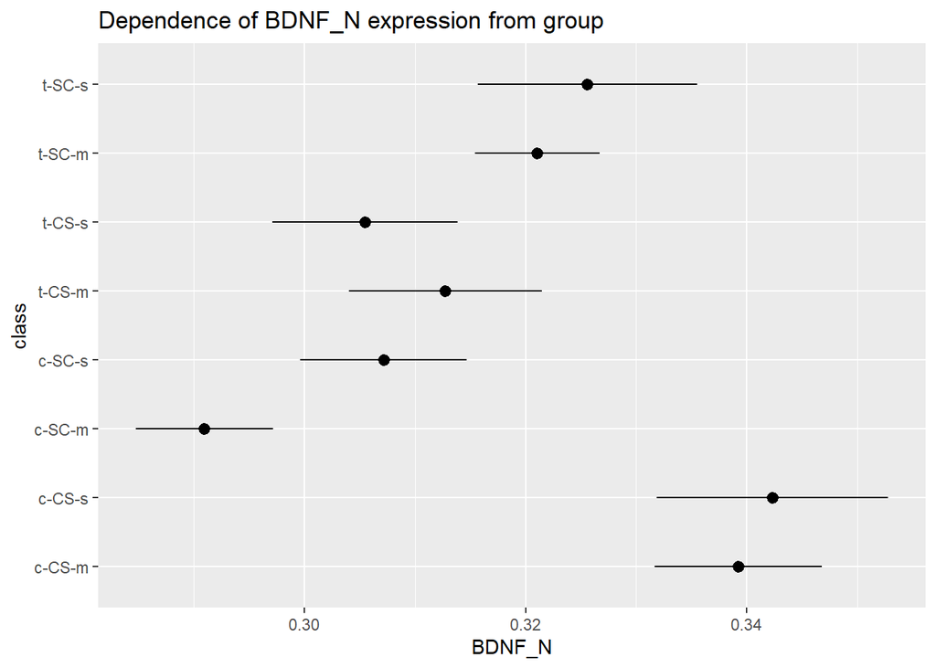

```r
ggplot(data = sdata, aes(x = BDNF_N , y = class)) +
  stat_summary(geom = 'pointrange', fun.data = mean_cl_normal, position = position_dodge(width = 0.2)) + ggtitle("Dependence of BDNF_N expression from group")
```

### 2.2 Analisys

```r
model <- lm(BDNF_N ~ class , data=sdata)
anova <- Anova(mod = model)
summary(anova)
```

```
##      Sum Sq             Df          F value          Pr(>F)
##  Min.   :0.2915   Min.   :   7   Min.   :18.95   Min.   :0
##  1st Qu.:0.7893   1st Qu.: 265   1st Qu.:18.95   1st Qu.:0
##  Median :1.2871   Median : 523   Median :18.95   Median :0
##  Mean   :1.2871   Mean   : 523   Mean   :18.95   Mean   :0
##  3rd Qu.:1.7850   3rd Qu.: 781   3rd Qu.:18.95   3rd Qu.:0
##  Max.   :2.2828   Max.   :1039   Max.   :18.95   Max.   :0
##                                  NA's   :1       NA's   :1
```

### 2.3 Conditions of applicability

There are no influential observations, the dispersion of the residues is homogeneous, the distribution of the residues is close to normal. This means that our linear model is quite applicable.

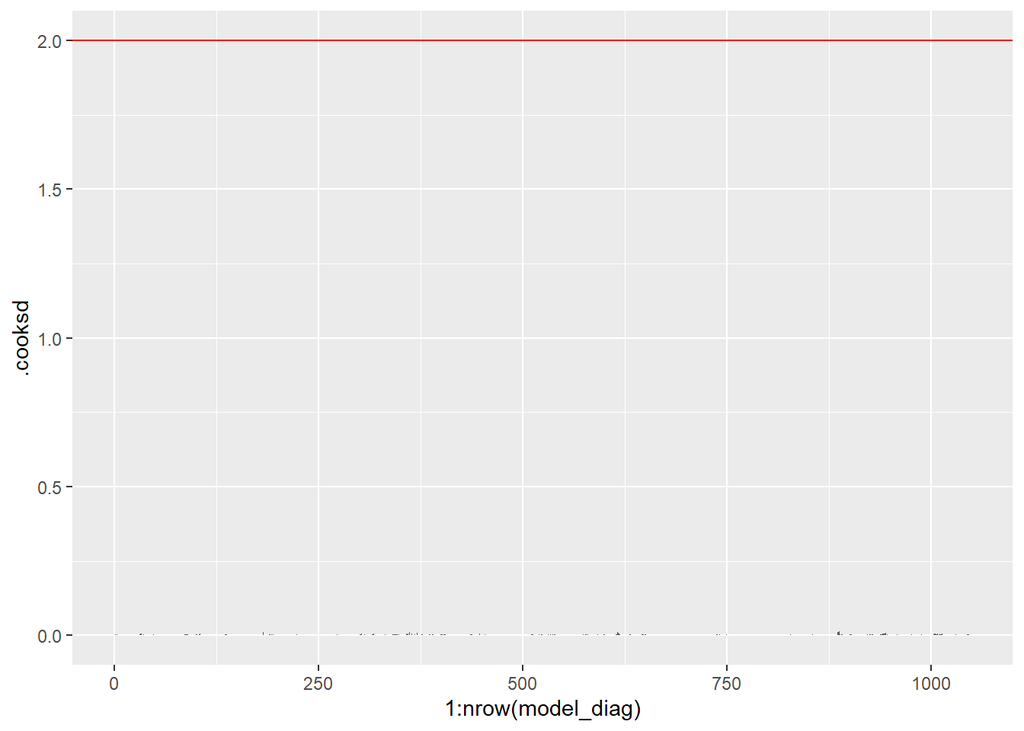

```r
model_diag <- fortify(model)

ggplot(model_diag, aes(x = 1:nrow(model_diag), y = .cooksd)) +
  geom_bar(stat = 'identity') +
  geom_hline(yintercept = 2, color = 'red')
```

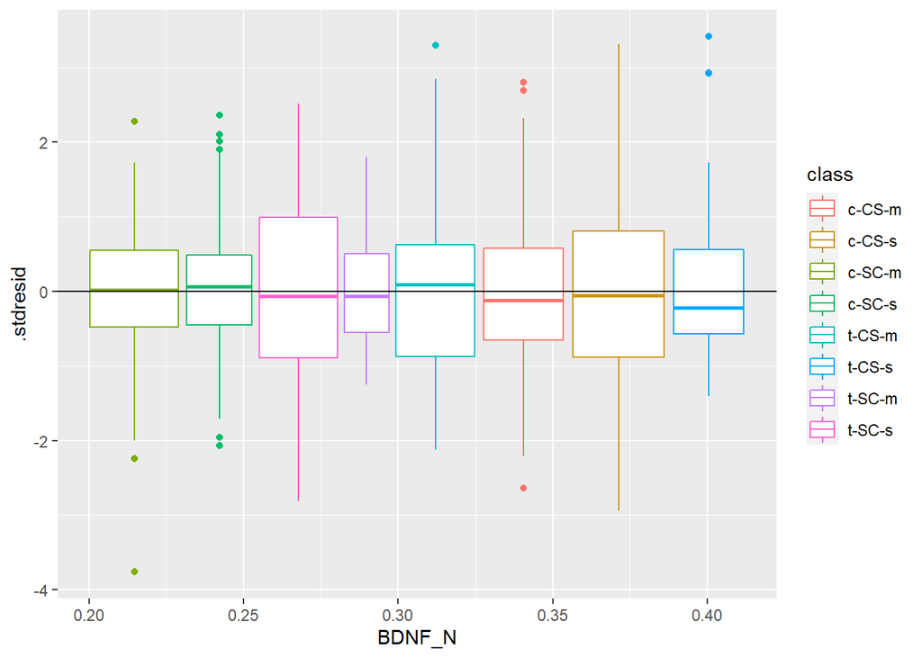

```r
ggplot(data = model_diag, aes(x = BDNF_N, y = .stdresid, color = class)) +
  geom_boxplot() + geom_hline(yintercept = 0)
```

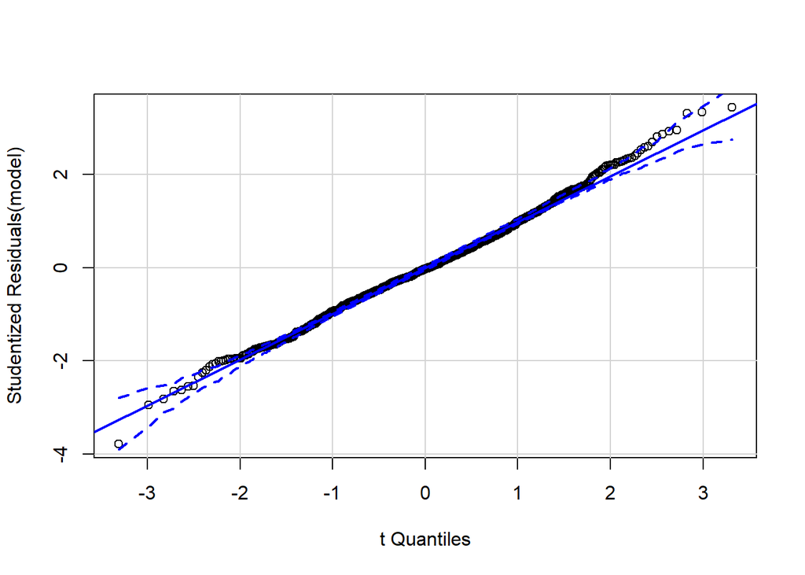

```r
qqPlot(model, id = FALSE)
```

### 2.4 Results

```r
anova
```

```
## Anova Table (Type II tests)
##
## Response: BDNF_N
##            Sum Sq   Df F value    Pr(>F)
## class     0.29147    7  18.951 < 2.2e-16 ***
## Residuals 2.28279 1039
## ---
## Signif. codes:  0 '***' 0.001 '**' 0.01 '*' 0.05 '.' 0.1 ' ' 1
```

**Experiments group significantly affects protein expression level: F =18.951 , p_value = 2.2e-16, df = 7**

### 2.4 Post-hoc tests

We found that the group is a significant factor in assessing BDNF_N expression. To see which groups differ from each other, we will use Tukey’s post-hoc test.

```r
fit_inter <- lm(BDNF_N ~ class - 1, data = sdata)
tukey <- glht(fit_inter, linfct = mcp(class= 'Tukey'))
summary(tukey)
```

```
##
##   Simultaneous Tests for General Linear Hypotheses
##
## Multiple Comparisons of Means: Tukey Contrasts
##
##
## Fit: lm(formula = BDNF_N ~ class - 1, data = sdata)
##
## Linear Hypotheses:
##                       Estimate Std. Error t value Pr(>|t|)
## c-CS-s - c-CS-m == 0  0.003099   0.005741   0.540   0.9994
## c-SC-m - c-CS-m == 0 -0.048272   0.005412  -8.919    <0.01 ***
## c-SC-s - c-CS-m == 0 -0.032054   0.005741  -5.584    <0.01 ***
## t-CS-m - c-CS-m == 0 -0.026485   0.005561  -4.763    <0.01 ***
## t-CS-s - c-CS-m == 0 -0.033757   0.005964  -5.660    <0.01 ***
## t-SC-m - c-CS-m == 0 -0.018154   0.005561  -3.265   0.0250 *
## t-SC-s - c-CS-m == 0 -0.013631   0.005594  -2.437   0.2241
## c-SC-m - c-CS-s == 0 -0.051371   0.005741  -8.948    <0.01 ***
## c-SC-s - c-CS-s == 0 -0.035153   0.006051  -5.809    <0.01 ***
## t-CS-m - c-CS-s == 0 -0.029584   0.005881  -5.031    <0.01 ***
## t-CS-s - c-CS-s == 0 -0.036856   0.006264  -5.884    <0.01 ***
## t-SC-m - c-CS-s == 0 -0.021253   0.005881  -3.614    <0.01 **
## t-SC-s - c-CS-s == 0 -0.016730   0.005912  -2.830   0.0886 .
## c-SC-s - c-SC-m == 0  0.016218   0.005741   2.825   0.0895 .
## t-CS-m - c-SC-m == 0  0.021786   0.005561   3.918    <0.01 **
## t-CS-s - c-SC-m == 0  0.014515   0.005964   2.434   0.2261
## t-SC-m - c-SC-m == 0  0.030118   0.005561   5.416    <0.01 ***
## t-SC-s - c-SC-m == 0  0.034641   0.005594   6.193    <0.01 ***
## t-CS-m - c-SC-s == 0  0.005569   0.005881   0.947   0.9812
## t-CS-s - c-SC-s == 0 -0.001703   0.006264  -0.272   1.0000
## t-SC-m - c-SC-s == 0  0.013900   0.005881   2.364   0.2596
## t-SC-s - c-SC-s == 0  0.018423   0.005912   3.116   0.0392 *
## t-CS-s - t-CS-m == 0 -0.007272   0.006099  -1.192   0.9340
## t-SC-m - t-CS-m == 0  0.008331   0.005705   1.460   0.8279
## t-SC-s - t-CS-m == 0  0.012854   0.005738   2.240   0.3277
## t-SC-m - t-CS-s == 0  0.015603   0.006099   2.558   0.1729
## t-SC-s - t-CS-s == 0  0.020126   0.006129   3.284   0.0238 *
## t-SC-s - t-SC-m == 0  0.004523   0.005738   0.788   0.9937
## ---
## Signif. codes:  0 '***' 0.001 '**' 0.01 '*' 0.05 '.' 0.1 ' ' 1
## (Adjusted p values reported -- single-step method)
```

### 2.5 Visualization of post-hos test

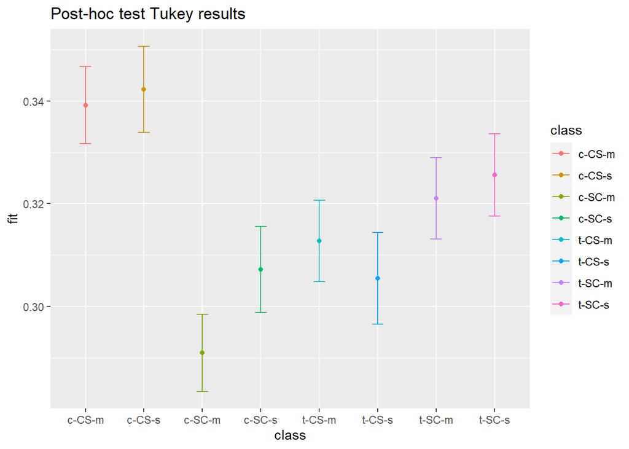

```r
MyData <- expand.grid(class = sdata$class)
MyData <- data.frame(
  MyData,
  predict(model, newdata = MyData, interval = 'confidence')
)

ggplot(data = MyData, aes(x = class, y = fit,
                          ymin = lwr, ymax = upr, colour = class)) +
  geom_point(position = position_dodge(width = 0.2)) +
  geom_errorbar(position = position_dodge(width = 0.2), width =0.2 ) +
  ggtitle('Post-hoc test Tukey results')
```

# 3. Dependence of expression level of ERBB4_N from other proteins

We will try to build a linear model that can predict the level ERBB4_N protein production based on data on other proteins in the experiment.  
We have a lot of predictors, so corralation matrix will be not informatively. We just start to build a linear model. Notice, that this is a very bad idea, because we have 70 predictors. It is obvious that we will have a lot of autocorrelations.

```r
lm1 <- lm(ERBB4_N ~ ., data = sdata[,-c(1, 73:76)])
summary(lm1)
```

```
##
## Call:
## lm(formula = ERBB4_N ~ ., data = sdata[, -c(1, 73:76)])
##
## Residuals:
##       Min        1Q    Median        3Q       Max
## -0.024804 -0.003836  0.000035  0.003535  0.038030
##
## Coefficients: (1 not defined because of singularities)
##                   Estimate Std. Error t value Pr(>|t|)
## (Intercept)      2.025e-02  5.706e-03   3.548 0.000406 ***
## DYRK1A_N        -7.525e-03  5.414e-03  -1.390 0.164857
## ITSN1_N          1.644e-02  6.034e-03   2.725 0.006538 **
## BDNF_N           9.525e-04  1.454e-02   0.066 0.947766
## NR1_N           -9.795e-03  3.919e-03  -2.500 0.012597 *
## NR2A_N          -1.052e-04  1.002e-03  -0.105 0.916429
## pAKT_N           3.774e-02  1.558e-02   2.423 0.015587 *
## pBRAF_N         -4.164e-02  2.248e-02  -1.853 0.064242 .
## pCAMKII_N        5.979e-05  4.636e-04   0.129 0.897396
## pCREB_N         -4.847e-02  2.014e-02  -2.407 0.016269 *
## pELK_N          -1.141e-03  9.689e-04  -1.178 0.239122
## pERK_N          -1.530e-03  2.626e-03  -0.583 0.560362
## pJNK_N          -2.303e-02  1.707e-02  -1.349 0.177607
## PKCA_N           5.193e-02  1.603e-02   3.239 0.001241 **
## pMEK_N          -7.971e-03  1.662e-02  -0.480 0.631679
## pNR1_N          -1.719e-02  8.958e-03  -1.919 0.055258 .
## pNR2A_N          1.253e-03  4.412e-03   0.284 0.776437
## pNR2B_N          5.446e-03  3.808e-03   1.430 0.152982
## pPKCAB_N         1.448e-03  1.913e-03   0.757 0.449083
## pRSK_N           1.468e-02  9.009e-03   1.630 0.103437
## AKT_N            1.140e-02  6.305e-03   1.808 0.070964 .
## BRAF_N          -1.516e-02  6.877e-03  -2.205 0.027690 *
## CAMKII_N         2.256e-02  1.381e-02   1.633 0.102738
## CREB_N          -4.746e-02  2.033e-02  -2.335 0.019740 *
## ELK_N            3.076e-04  2.790e-03   0.110 0.912255
## ERK_N            4.707e-03  1.693e-03   2.780 0.005540 **
## GSK3B_N          5.570e-03  4.192e-03   1.329 0.184223
## JNK_N            2.053e-02  2.349e-02   0.874 0.382285
## MEK_N           -2.572e-03  1.553e-02  -0.166 0.868452
## TRKA_N          -6.652e-03  8.830e-03  -0.753 0.451426
```

[output cut: 32 more lines]

```
## pCASP9_N         1.245e-02  2.175e-03   5.726 1.37e-08 ***
## PSD95_N          2.225e-02  2.247e-03   9.903  < 2e-16 ***
## SNCA_N           7.527e-03  2.318e-02   0.325 0.745482
## Ubiquitin_N     -1.681e-03  3.327e-03  -0.505 0.613420
## pGSK3B_Tyr216_N  1.618e-02  6.614e-03   2.447 0.014586 *
## SHH_N            2.189e-03  1.244e-02   0.176 0.860324
## pS6_N                   NA         NA      NA       NA
## SYP_N            1.934e-02  6.402e-03   3.021 0.002589 **
## CaNA_N          -6.888e-03  2.422e-03  -2.844 0.004548 **
## ---
## Signif. codes:  0 '***' 0.001 '**' 0.01 '*' 0.05 '.' 0.1 ' ' 1
##
## Residual standard error: 0.006625 on 977 degrees of freedom
## Multiple R-squared:  0.8224, Adjusted R-squared:  0.8098
## F-statistic: 65.55 on 69 and 977 DF,  p-value: < 2.2e-16
```

Adjusted R-squared: 0.8098

## 3.2 Searching for an optimal model

### 3.2.1 Step-by-step selection of predictors by significance

We will use backward selection to select significant predictors. The selection criterion is a private F-test. We will remove the predictor from the model if it does not significantly affect the amount of variability explained by the model.

```r
drop1(lm1, test = "F")
```

```
## Single term deletions
##
## Model:
## ERBB4_N ~ DYRK1A_N + ITSN1_N + BDNF_N + NR1_N + NR2A_N + pAKT_N +
##     pBRAF_N + pCAMKII_N + pCREB_N + pELK_N + pERK_N + pJNK_N +
##     PKCA_N + pMEK_N + pNR1_N + pNR2A_N + pNR2B_N + pPKCAB_N +
##     pRSK_N + AKT_N + BRAF_N + CAMKII_N + CREB_N + ELK_N + ERK_N +
##     GSK3B_N + JNK_N + MEK_N + TRKA_N + RSK_N + APP_N + Bcatenin_N +
##     SOD1_N + MTOR_N + P38_N + pMTOR_N + DSCR1_N + AMPKA_N + NR2B_N +
##     pNUMB_N + RAPTOR_N + TIAM1_N + pP70S6_N + NUMB_N + P70S6_N +
##     pGSK3B_N + pPKCG_N + CDK5_N + S6_N + ADARB1_N + AcetylH3K9_N +
##     RRP1_N + BAX_N + ARC_N + nNOS_N + Tau_N + GFAP_N + GluR3_N +
##     GluR4_N + IL1B_N + P3525_N + pCASP9_N + PSD95_N + SNCA_N +
##     Ubiquitin_N + pGSK3B_Tyr216_N + SHH_N + pS6_N + SYP_N + CaNA_N
##                 Df Sum of Sq      RSS    AIC F value    Pr(>F)
## <none>                       0.042882 -10438
## DYRK1A_N         1 0.0000848 0.042967 -10438  1.9320  0.164857
## ITSN1_N          1 0.0003260 0.043208 -10432  7.4274  0.006538 **
## BDNF_N           1 0.0000002 0.042883 -10440  0.0043  0.947766
## NR1_N            1 0.0002742 0.043157 -10433  6.2479  0.012597 *
## NR2A_N           1 0.0000005 0.042883 -10440  0.0110  0.916429
## pAKT_N           1 0.0002576 0.043140 -10434  5.8695  0.015587 *
## pBRAF_N          1 0.0001506 0.043033 -10436  3.4321  0.064242 .
## pCAMKII_N        1 0.0000007 0.042883 -10440  0.0166  0.897396
## pCREB_N          1 0.0002543 0.043137 -10434  5.7936  0.016269 *
## pELK_N           1 0.0000609 0.042943 -10438  1.3875  0.239122
## pERK_N           1 0.0000149 0.042897 -10440  0.3393  0.560362
## pJNK_N           1 0.0000799 0.042962 -10438  1.8202  0.177607
## PKCA_N           1 0.0004604 0.043343 -10429 10.4889  0.001241 **
## pMEK_N           1 0.0000101 0.042892 -10440  0.2299  0.631679
## pNR1_N           1 0.0001617 0.043044 -10436  3.6831  0.055258 .
## pNR2A_N          1 0.0000035 0.042886 -10440  0.0807  0.776437
## pNR2B_N          1 0.0000898 0.042972 -10438  2.0454  0.152982
## pPKCAB_N         1 0.0000252 0.042908 -10439  0.5734  0.449083
## pRSK_N           1 0.0001166 0.042999 -10437  2.6567  0.103437
## AKT_N            1 0.0001434 0.043026 -10436  3.2677  0.070964 .
## BRAF_N           1 0.0002134 0.043096 -10435  4.8618  0.027690 *
## CAMKII_N         1 0.0001171 0.042999 -10437  2.6675  0.102738
## CREB_N           1 0.0002393 0.043122 -10434  5.4526  0.019740 *
## ELK_N            1 0.0000005 0.042883 -10440  0.0121  0.912255
```

[output cut: 33 more lines]

```
## GluR3_N          1 0.0003445 0.043227 -10431  7.8497  0.005183 **
## GluR4_N          1 0.0001211 0.043003 -10437  2.7585  0.097060 .
## IL1B_N           1 0.0003425 0.043225 -10432  7.8043  0.005314 **
## P3525_N          1 0.0013549 0.044237 -10407 30.8686 3.560e-08 ***
## pCASP9_N         1 0.0014389 0.044321 -10405 32.7817 1.372e-08 ***
## PSD95_N          1 0.0043045 0.047187 -10340 98.0707 < 2.2e-16 ***
## SNCA_N           1 0.0000046 0.042887 -10440  0.1054  0.745482
## Ubiquitin_N      1 0.0000112 0.042894 -10440  0.2554  0.613420
## pGSK3B_Tyr216_N  1 0.0002628 0.043145 -10433  5.9872  0.014586 *
## SHH_N            1 0.0000014 0.042884 -10440  0.0310  0.860324
## pS6_N            0 0.0000000 0.042882 -10438
## SYP_N            1 0.0004005 0.043283 -10430  9.1236  0.002589 **
## CaNA_N           1 0.0003550 0.043237 -10431  8.0883  0.004548 **
## ---
## Signif. codes:  0 '***' 0.001 '**' 0.01 '*' 0.05 '.' 0.1 ' ' 1
```

```r
summary(lm1)
```

```
##
## Call:
## lm(formula = ERBB4_N ~ ., data = sdata[, -c(1, 73:76)])
##
## Residuals:
##       Min        1Q    Median        3Q       Max
## -0.024804 -0.003836  0.000035  0.003535  0.038030
##
## Coefficients: (1 not defined because of singularities)
##                   Estimate Std. Error t value Pr(>|t|)
## (Intercept)      2.025e-02  5.706e-03   3.548 0.000406 ***
## DYRK1A_N        -7.525e-03  5.414e-03  -1.390 0.164857
## ITSN1_N          1.644e-02  6.034e-03   2.725 0.006538 **
## BDNF_N           9.525e-04  1.454e-02   0.066 0.947766
## NR1_N           -9.795e-03  3.919e-03  -2.500 0.012597 *
## NR2A_N          -1.052e-04  1.002e-03  -0.105 0.916429
## pAKT_N           3.774e-02  1.558e-02   2.423 0.015587 *
## pBRAF_N         -4.164e-02  2.248e-02  -1.853 0.064242 .
## pCAMKII_N        5.979e-05  4.636e-04   0.129 0.897396
## pCREB_N         -4.847e-02  2.014e-02  -2.407 0.016269 *
## pELK_N          -1.141e-03  9.689e-04  -1.178 0.239122
## pERK_N          -1.530e-03  2.626e-03  -0.583 0.560362
## pJNK_N          -2.303e-02  1.707e-02  -1.349 0.177607
## PKCA_N           5.193e-02  1.603e-02   3.239 0.001241 **
## pMEK_N          -7.971e-03  1.662e-02  -0.480 0.631679
## pNR1_N          -1.719e-02  8.958e-03  -1.919 0.055258 .
## pNR2A_N          1.253e-03  4.412e-03   0.284 0.776437
## pNR2B_N          5.446e-03  3.808e-03   1.430 0.152982
## pPKCAB_N         1.448e-03  1.913e-03   0.757 0.449083
## pRSK_N           1.468e-02  9.009e-03   1.630 0.103437
## AKT_N            1.140e-02  6.305e-03   1.808 0.070964 .
## BRAF_N          -1.516e-02  6.877e-03  -2.205 0.027690 *
## CAMKII_N         2.256e-02  1.381e-02   1.633 0.102738
## CREB_N          -4.746e-02  2.033e-02  -2.335 0.019740 *
## ELK_N            3.076e-04  2.790e-03   0.110 0.912255
## ERK_N            4.707e-03  1.693e-03   2.780 0.005540 **
## GSK3B_N          5.570e-03  4.192e-03   1.329 0.184223
## JNK_N            2.053e-02  2.349e-02   0.874 0.382285
## MEK_N           -2.572e-03  1.553e-02  -0.166 0.868452
## TRKA_N          -6.652e-03  8.830e-03  -0.753 0.451426
```

[output cut: 32 more lines]

```
## pCASP9_N         1.245e-02  2.175e-03   5.726 1.37e-08 ***
## PSD95_N          2.225e-02  2.247e-03   9.903  < 2e-16 ***
## SNCA_N           7.527e-03  2.318e-02   0.325 0.745482
## Ubiquitin_N     -1.681e-03  3.327e-03  -0.505 0.613420
## pGSK3B_Tyr216_N  1.618e-02  6.614e-03   2.447 0.014586 *
## SHH_N            2.189e-03  1.244e-02   0.176 0.860324
## pS6_N                   NA         NA      NA       NA
## SYP_N            1.934e-02  6.402e-03   3.021 0.002589 **
## CaNA_N          -6.888e-03  2.422e-03  -2.844 0.004548 **
## ---
## Signif. codes:  0 '***' 0.001 '**' 0.01 '*' 0.05 '.' 0.1 ' ' 1
##
## Residual standard error: 0.006625 on 977 degrees of freedom
## Multiple R-squared:  0.8224, Adjusted R-squared:  0.8098
## F-statistic: 65.55 on 69 and 977 DF,  p-value: < 2.2e-16
```

```r
lm2 <- update(lm1, .~.-DYRK1A_N-BDNF_N-NR2A_N-pBRAF_N-pCAMKII_N-pELK_N-pERK_N-
               pJNK_N-pMEK_N-pNR1_N-pNR2A_N-pNR2B_N-pPKCAB_N-pRSK_N-
               AKT_N-CAMKII_N-ELK_N-GSK3B_N-JNK_N-MEK_N-TRKA_N-APP_N-
               Bcatenin_N-SOD1_N-P38_N- DSCR1_N-AMPKA_N-NR2B_N-pNUMB_N-
               RAPTOR_N-TIAM1_N-pP70S6_N-NUMB_N-P70S6_N-CDK5_N-S6_N-ADARB1_N-
               BAX_N-ARC_N-nNOS_N-GluR4_N-SNCA_N-Ubiquitin_N-SHH_N-pS6_N)
drop1(lm2, test = "F")
```

```
## Single term deletions
##
## Model:
## ERBB4_N ~ ITSN1_N + NR1_N + pAKT_N + pCREB_N + PKCA_N + BRAF_N +
##     CREB_N + ERK_N + RSK_N + MTOR_N + pMTOR_N + pGSK3B_N + pPKCG_N +
##     AcetylH3K9_N + RRP1_N + Tau_N + GFAP_N + GluR3_N + IL1B_N +
##     P3525_N + pCASP9_N + PSD95_N + pGSK3B_Tyr216_N + SYP_N +
##     CaNA_N
##                 Df Sum of Sq      RSS    AIC  F value    Pr(>F)
## <none>                       0.048358 -10400
## ITSN1_N          1 0.0000583 0.048416 -10401   1.2300 0.2676759
## NR1_N            1 0.0009263 0.049284 -10382  19.5566 1.081e-05 ***
## pAKT_N           1 0.0011377 0.049496 -10378  24.0209 1.108e-06 ***
## pCREB_N          1 0.0011418 0.049500 -10378  24.1080 1.060e-06 ***
## PKCA_N           1 0.0017737 0.050132 -10364  37.4497 1.335e-09 ***
## BRAF_N           1 0.0004300 0.048788 -10393   9.0780 0.0026508 **
## CREB_N           1 0.0003757 0.048734 -10394   7.9326 0.0049489 **
## ERK_N            1 0.0014755 0.049833 -10370  31.1530 3.055e-08 ***
## RSK_N            1 0.0001873 0.048545 -10398   3.9546 0.0470103 *
## MTOR_N           1 0.0010212 0.049379 -10380  21.5611 3.874e-06 ***
## pMTOR_N          1 0.0008633 0.049221 -10384  18.2270 2.143e-05 ***
## pGSK3B_N         1 0.0007326 0.049091 -10386  15.4680 8.958e-05 ***
## pPKCG_N          1 0.0042425 0.052600 -10314  89.5747 < 2.2e-16 ***
## AcetylH3K9_N     1 0.0008509 0.049209 -10384  17.9647 2.454e-05 ***
## RRP1_N           1 0.0004798 0.048838 -10392  10.1308 0.0015022 **
## Tau_N            1 0.0010560 0.049414 -10379  22.2955 2.664e-06 ***
## GFAP_N           1 0.0005255 0.048883 -10391  11.0947 0.0008968 ***
## GluR3_N          1 0.0015290 0.049887 -10369  32.2834 1.737e-08 ***
## IL1B_N           1 0.0019540 0.050312 -10360  41.2548 2.045e-10 ***
## P3525_N          1 0.0026813 0.051039 -10346  56.6117 1.162e-13 ***
## pCASP9_N         1 0.0016656 0.050024 -10366  35.1669 4.138e-09 ***
## PSD95_N          1 0.0109794 0.059337 -10188 231.8120 < 2.2e-16 ***
## pGSK3B_Tyr216_N  1 0.0017467 0.050105 -10365  36.8798 1.770e-09 ***
## SYP_N            1 0.0006575 0.049015 -10388  13.8828 0.0002052 ***
## CaNA_N           1 0.0013714 0.049729 -10373  28.9540 9.192e-08 ***
## ---
## Signif. codes:  0 '***' 0.001 '**' 0.01 '*' 0.05 '.' 0.1 ' ' 1
```

```r
summary(lm2)
```

```
##
## Call:
## lm(formula = ERBB4_N ~ ITSN1_N + NR1_N + pAKT_N + pCREB_N + PKCA_N +
##     BRAF_N + CREB_N + ERK_N + RSK_N + MTOR_N + pMTOR_N + pGSK3B_N +
##     pPKCG_N + AcetylH3K9_N + RRP1_N + Tau_N + GFAP_N + GluR3_N +
##     IL1B_N + P3525_N + pCASP9_N + PSD95_N + pGSK3B_Tyr216_N +
##     SYP_N + CaNA_N, data = sdata[, -c(1, 73:76)])
##
## Residuals:
##       Min        1Q    Median        3Q       Max
## -0.030534 -0.004433  0.000222  0.004103  0.038017
##
## Coefficients:
##                   Estimate Std. Error t value Pr(>|t|)
## (Intercept)      0.0180421  0.0043718   4.127 3.98e-05 ***
## ITSN1_N          0.0042612  0.0038422   1.109 0.267676
## NR1_N           -0.0082338  0.0018619  -4.422 1.08e-05 ***
## pAKT_N           0.0581811  0.0118710   4.901 1.11e-06 ***
## pCREB_N         -0.0700022  0.0142571  -4.910 1.06e-06 ***
## PKCA_N           0.0700722  0.0114504   6.120 1.34e-09 ***
## BRAF_N          -0.0119387  0.0039624  -3.013 0.002651 **
## CREB_N          -0.0461654  0.0163912  -2.816 0.004949 **
## ERK_N            0.0056878  0.0010190   5.581 3.06e-08 ***
## RSK_N            0.0406475  0.0204401   1.989 0.047010 *
## MTOR_N           0.0383902  0.0082677   4.643 3.87e-06 ***
## pMTOR_N         -0.0184799  0.0043286  -4.269 2.14e-05 ***
## pGSK3B_N         0.0882994  0.0224512   3.933 8.96e-05 ***
## pPKCG_N         -0.0077723  0.0008212  -9.464  < 2e-16 ***
## AcetylH3K9_N     0.0129558  0.0030567   4.238 2.45e-05 ***
## RRP1_N          -0.0273296  0.0085864  -3.183 0.001502 **
## Tau_N            0.0386606  0.0081877   4.722 2.66e-06 ***
## GFAP_N          -0.0868144  0.0260636  -3.331 0.000897 ***
## GluR3_N         -0.0526795  0.0092715  -5.682 1.74e-08 ***
## IL1B_N           0.0362642  0.0056460   6.423 2.04e-10 ***
## P3525_N          0.0912450  0.0121271   7.524 1.16e-13 ***
## pCASP9_N         0.0095649  0.0016129   5.930 4.14e-09 ***
## PSD95_N          0.0250564  0.0016457  15.225  < 2e-16 ***
## pGSK3B_Tyr216_N  0.0268621  0.0044233   6.073 1.77e-09 ***
## SYP_N            0.0190266  0.0051065   3.726 0.000205 ***
## CaNA_N          -0.0080522  0.0014964  -5.381 9.19e-08 ***
## ---
## Signif. codes:  0 '***' 0.001 '**' 0.01 '*' 0.05 '.' 0.1 ' ' 1
##
## Residual standard error: 0.006882 on 1021 degrees of freedom
## Multiple R-squared:  0.7997, Adjusted R-squared:  0.7948
## F-statistic:   163 on 25 and 1021 DF,  p-value: < 2.2e-16
```

```r
lm3 <- update(lm2, .~. -ITSN1_N)
drop1(lm3, test = "F")
```

```
## Single term deletions
##
## Model:
## ERBB4_N ~ NR1_N + pAKT_N + pCREB_N + PKCA_N + BRAF_N + CREB_N +
##     ERK_N + RSK_N + MTOR_N + pMTOR_N + pGSK3B_N + pPKCG_N + AcetylH3K9_N +
##     RRP1_N + Tau_N + GFAP_N + GluR3_N + IL1B_N + P3525_N + pCASP9_N +
##     PSD95_N + pGSK3B_Tyr216_N + SYP_N + CaNA_N
##                 Df Sum of Sq      RSS    AIC  F value    Pr(>F)
## <none>                       0.048416 -10401
## NR1_N            1 0.0008731 0.049289 -10384  18.4301 1.930e-05 ***
## pAKT_N           1 0.0010955 0.049512 -10379  23.1236 1.747e-06 ***
## pCREB_N          1 0.0010850 0.049501 -10380  22.9025 1.955e-06 ***
## PKCA_N           1 0.0017968 0.050213 -10365  37.9283 1.053e-09 ***
## BRAF_N           1 0.0012068 0.049623 -10377  25.4749 5.303e-07 ***
## CREB_N           1 0.0003536 0.048770 -10395   7.4636 0.0064046 **
## ERK_N            1 0.0017612 0.050177 -10365  37.1762 1.528e-09 ***
## RSK_N            1 0.0001427 0.048559 -10400   3.0112 0.0829917 .
## MTOR_N           1 0.0009968 0.049413 -10381  21.0401 5.055e-06 ***
## pMTOR_N          1 0.0008800 0.049296 -10384  18.5761 1.790e-05 ***
## pGSK3B_N         1 0.0007413 0.049157 -10387  15.6470 8.160e-05 ***
## pPKCG_N          1 0.0041894 0.052605 -10316  88.4317 < 2.2e-16 ***
## AcetylH3K9_N     1 0.0008245 0.049241 -10385  17.4041 3.278e-05 ***
## RRP1_N           1 0.0005010 0.048917 -10392  10.5751 0.0011837 **
## Tau_N            1 0.0011310 0.049547 -10379  23.8739 1.193e-06 ***
## GFAP_N           1 0.0005259 0.048942 -10391  11.1013 0.0008936 ***
## GluR3_N          1 0.0016007 0.050017 -10369  33.7886 8.205e-09 ***
## IL1B_N           1 0.0019695 0.050386 -10361  41.5735 1.748e-10 ***
## P3525_N          1 0.0026587 0.051075 -10347  56.1226 1.470e-13 ***
## pCASP9_N         1 0.0017443 0.050160 -10366  36.8209 1.822e-09 ***
## PSD95_N          1 0.0109373 0.059353 -10190 230.8727 < 2.2e-16 ***
## pGSK3B_Tyr216_N  1 0.0018763 0.050292 -10363  39.6071 4.600e-10 ***
## SYP_N            1 0.0006163 0.049032 -10390  13.0097 0.0003249 ***
## CaNA_N           1 0.0014166 0.049833 -10372  29.9025 5.711e-08 ***
## ---
## Signif. codes:  0 '***' 0.001 '**' 0.01 '*' 0.05 '.' 0.1 ' ' 1
```

```r
summary(lm3)
```

```
##
## Call:
## lm(formula = ERBB4_N ~ NR1_N + pAKT_N + pCREB_N + PKCA_N + BRAF_N +
##     CREB_N + ERK_N + RSK_N + MTOR_N + pMTOR_N + pGSK3B_N + pPKCG_N +
##     AcetylH3K9_N + RRP1_N + Tau_N + GFAP_N + GluR3_N + IL1B_N +
##     P3525_N + pCASP9_N + PSD95_N + pGSK3B_Tyr216_N + SYP_N +
##     CaNA_N, data = sdata[, -c(1, 73:76)])
##
## Residuals:
##       Min        1Q    Median        3Q       Max
## -0.030421 -0.004370  0.000265  0.004017  0.037469
##
## Coefficients:
##                   Estimate Std. Error t value Pr(>|t|)
## (Intercept)      0.0184270  0.0043585   4.228 2.57e-05 ***
## NR1_N           -0.0078666  0.0018324  -4.293 1.93e-05 ***
## pAKT_N           0.0567543  0.0118024   4.809 1.75e-06 ***
## pCREB_N         -0.0669748  0.0139949  -4.786 1.96e-06 ***
## PKCA_N           0.0704885  0.0114456   6.159 1.05e-09 ***
## BRAF_N          -0.0079017  0.0015655  -5.047 5.30e-07 ***
## CREB_N          -0.0446235  0.0163339  -2.732 0.006405 **
## ERK_N            0.0059891  0.0009823   6.097 1.53e-09 ***
## RSK_N            0.0338323  0.0194967   1.735 0.082992 .
## MTOR_N           0.0378657  0.0082551   4.587 5.06e-06 ***
## pMTOR_N         -0.0186469  0.0043264  -4.310 1.79e-05 ***
## pGSK3B_N         0.0888007  0.0224492   3.956 8.16e-05 ***
## pPKCG_N         -0.0076969  0.0008185  -9.404  < 2e-16 ***
## AcetylH3K9_N     0.0127236  0.0030499   4.172 3.28e-05 ***
## RRP1_N          -0.0278790  0.0085731  -3.252 0.001184 **
## Tau_N            0.0397312  0.0081315   4.886 1.19e-06 ***
## GFAP_N          -0.0868498  0.0260665  -3.332 0.000894 ***
## GluR3_N         -0.0536560  0.0092307  -5.813 8.21e-09 ***
## IL1B_N           0.0363996  0.0056453   6.448 1.75e-10 ***
## P3525_N          0.0908134  0.0121222   7.492 1.47e-13 ***
## pCASP9_N         0.0097409  0.0016053   6.068 1.82e-09 ***
## PSD95_N          0.0248537  0.0016357  15.194  < 2e-16 ***
## pGSK3B_Tyr216_N  0.0275587  0.0043790   6.293 4.60e-10 ***
## SYP_N            0.0182440  0.0050581   3.607 0.000325 ***
## CaNA_N          -0.0081650  0.0014932  -5.468 5.71e-08 ***
## ---
## Signif. codes:  0 '***' 0.001 '**' 0.01 '*' 0.05 '.' 0.1 ' ' 1
##
## Residual standard error: 0.006883 on 1022 degrees of freedom
## Multiple R-squared:  0.7994, Adjusted R-squared:  0.7947
## F-statistic: 169.7 on 24 and 1022 DF,  p-value: < 2.2e-16
```

```r
lm4 <- update(lm3, .~. -RSK_N)
drop1(lm4, test = "F")
```

```
## Single term deletions
##
## Model:
## ERBB4_N ~ NR1_N + pAKT_N + pCREB_N + PKCA_N + BRAF_N + CREB_N +
##     ERK_N + MTOR_N + pMTOR_N + pGSK3B_N + pPKCG_N + AcetylH3K9_N +
##     RRP1_N + Tau_N + GFAP_N + GluR3_N + IL1B_N + P3525_N + pCASP9_N +
##     PSD95_N + pGSK3B_Tyr216_N + SYP_N + CaNA_N
##                 Df Sum of Sq      RSS    AIC  F value    Pr(>F)
## <none>                       0.048559 -10400
## NR1_N            1 0.0007516 0.049310 -10386  15.8349 7.399e-05 ***
## pAKT_N           1 0.0019114 0.050470 -10361  40.2671 3.322e-10 ***
## pCREB_N          1 0.0009428 0.049502 -10382  19.8614 9.245e-06 ***
## PKCA_N           1 0.0016918 0.050251 -10366  35.6410 3.268e-09 ***
## BRAF_N           1 0.0012070 0.049766 -10376  25.4288 5.427e-07 ***
## CREB_N           1 0.0002513 0.048810 -10396   5.2951 0.0215858 *
## ERK_N            1 0.0016205 0.050179 -10367  34.1399 6.888e-09 ***
## MTOR_N           1 0.0010541 0.049613 -10379  22.2061 2.787e-06 ***
## pMTOR_N          1 0.0008914 0.049450 -10383  18.7797 1.612e-05 ***
## pGSK3B_N         1 0.0008206 0.049379 -10384  17.2887 3.480e-05 ***
## pPKCG_N          1 0.0042693 0.052828 -10313  89.9418 < 2.2e-16 ***
## AcetylH3K9_N     1 0.0007891 0.049348 -10385  16.6243 4.910e-05 ***
## RRP1_N           1 0.0005261 0.049085 -10390  11.0825 0.0009025 ***
## Tau_N            1 0.0011387 0.049698 -10377  23.9901 1.125e-06 ***
## GFAP_N           1 0.0004935 0.049052 -10391  10.3973 0.0013019 **
## GluR3_N          1 0.0020105 0.050569 -10359  42.3562 1.189e-10 ***
## IL1B_N           1 0.0021157 0.050674 -10357  44.5712 4.015e-11 ***
## P3525_N          1 0.0025420 0.051101 -10348  53.5521 5.084e-13 ***
## pCASP9_N         1 0.0016062 0.050165 -10368  33.8389 8.000e-09 ***
## PSD95_N          1 0.0108349 0.059394 -10191 228.2619 < 2.2e-16 ***
## pGSK3B_Tyr216_N  1 0.0018080 0.050367 -10363  38.0902 9.721e-10 ***
## SYP_N            1 0.0007076 0.049266 -10386  14.9080 0.0001200 ***
## CaNA_N           1 0.0012744 0.049833 -10374  26.8487 2.650e-07 ***
## ---
## Signif. codes:  0 '***' 0.001 '**' 0.01 '*' 0.05 '.' 0.1 ' ' 1
```

```r
summary(lm4)
```

```
##
## Call:
## lm(formula = ERBB4_N ~ NR1_N + pAKT_N + pCREB_N + PKCA_N + BRAF_N +
##     CREB_N + ERK_N + MTOR_N + pMTOR_N + pGSK3B_N + pPKCG_N +
##     AcetylH3K9_N + RRP1_N + Tau_N + GFAP_N + GluR3_N + IL1B_N +
##     P3525_N + pCASP9_N + PSD95_N + pGSK3B_Tyr216_N + SYP_N +
##     CaNA_N, data = sdata[, -c(1, 73:76)])
##
## Residuals:
##       Min        1Q    Median        3Q       Max
## -0.029679 -0.004287  0.000277  0.004112  0.037375
##
## Coefficients:
##                   Estimate Std. Error t value Pr(>|t|)
## (Intercept)      0.0190645  0.0043473   4.385 1.28e-05 ***
## NR1_N           -0.0070604  0.0017743  -3.979 7.40e-05 ***
## pAKT_N           0.0663091  0.0104496   6.346 3.32e-10 ***
## pCREB_N         -0.0577202  0.0129516  -4.457 9.24e-06 ***
## PKCA_N           0.0677382  0.0113464   5.970 3.27e-09 ***
## BRAF_N          -0.0079023  0.0015671  -5.043 5.43e-07 ***
## CREB_N          -0.0357177  0.0155219  -2.301 0.021586 *
## ERK_N            0.0054496  0.0009327   5.843 6.89e-09 ***
## MTOR_N           0.0388474  0.0082438   4.712 2.79e-06 ***
## pMTOR_N         -0.0187649  0.0043301  -4.334 1.61e-05 ***
## pGSK3B_N         0.0929129  0.0223457   4.158 3.48e-05 ***
## pPKCG_N         -0.0077619  0.0008184  -9.484  < 2e-16 ***
## AcetylH3K9_N     0.0124281  0.0030481   4.077 4.91e-05 ***
## RRP1_N          -0.0285400  0.0085730  -3.329 0.000903 ***
## Tau_N            0.0398651  0.0081391   4.898 1.12e-06 ***
## GFAP_N          -0.0839621  0.0260389  -3.224 0.001302 **
## GluR3_N         -0.0579416  0.0089029  -6.508 1.19e-10 ***
## IL1B_N           0.0374912  0.0056157   6.676 4.02e-11 ***
## P3525_N          0.0879971  0.0120249   7.318 5.08e-13 ***
## pCASP9_N         0.0090823  0.0015613   5.817 8.00e-09 ***
## PSD95_N          0.0247014  0.0016350  15.108  < 2e-16 ***
## pGSK3B_Tyr216_N  0.0269715  0.0043702   6.172 9.72e-10 ***
## SYP_N            0.0193834  0.0050202   3.861 0.000120 ***
## CaNA_N          -0.0073884  0.0014259  -5.182 2.65e-07 ***
## ---
## Signif. codes:  0 '***' 0.001 '**' 0.01 '*' 0.05 '.' 0.1 ' ' 1
##
## Residual standard error: 0.00689 on 1023 degrees of freedom
## Multiple R-squared:  0.7988, Adjusted R-squared:  0.7943
## F-statistic: 176.6 on 23 and 1023 DF,  p-value: < 2.2e-16
```

### 3.2.2 Сhecking multicollinearity of predictors

The absence of collinearity between predictors is one of the conditions for the applicability of the linear model. Therefore, our next step is to check this condition and remove collinear predictors from the model.

```r
vif(lm4)
```

```
##           NR1_N          pAKT_N         pCREB_N          PKCA_N          BRAF_N
##        8.543677        3.970387        3.995826        7.547495        2.589545
##          CREB_N           ERK_N          MTOR_N         pMTOR_N        pGSK3B_N
##        3.737315        8.320438        6.481489        6.329984        4.180675
##         pPKCG_N    AcetylH3K9_N          RRP1_N           Tau_N          GFAP_N
##        4.879196        7.169350        1.685856        6.968296        2.681406
##         GluR3_N          IL1B_N         P3525_N        pCASP9_N         PSD95_N
##        2.161904        4.801829        2.869049        3.332069        3.840310
## pGSK3B_Tyr216_N           SYP_N          CaNA_N
##        3.804532        2.479694        4.612161
```

```r
lm5 <- update(lm4, .~.-NR1_N)
drop1(lm5)
```

```
## Single term deletions
##
## Model:
## ERBB4_N ~ pAKT_N + pCREB_N + PKCA_N + BRAF_N + CREB_N + ERK_N +
##     MTOR_N + pMTOR_N + pGSK3B_N + pPKCG_N + AcetylH3K9_N + RRP1_N +
##     Tau_N + GFAP_N + GluR3_N + IL1B_N + P3525_N + pCASP9_N +
##     PSD95_N + pGSK3B_Tyr216_N + SYP_N + CaNA_N
##                 Df Sum of Sq      RSS    AIC
## <none>                       0.049310 -10386
## pAKT_N           1 0.0020317 0.051342 -10345
## pCREB_N          1 0.0016982 0.051009 -10352
## PKCA_N           1 0.0013073 0.050618 -10360
## BRAF_N           1 0.0014317 0.050742 -10358
## CREB_N           1 0.0001908 0.049501 -10384
## ERK_N            1 0.0008930 0.050203 -10369
## MTOR_N           1 0.0006862 0.049997 -10373
## pMTOR_N          1 0.0008082 0.050119 -10371
## pGSK3B_N         1 0.0009081 0.050219 -10368
## pPKCG_N          1 0.0039436 0.053254 -10307
## AcetylH3K9_N     1 0.0005434 0.049854 -10376
## RRP1_N           1 0.0006369 0.049947 -10374
## Tau_N            1 0.0015052 0.050816 -10356
## GFAP_N           1 0.0003496 0.049660 -10380
## GluR3_N          1 0.0026577 0.051968 -10333
## IL1B_N           1 0.0027468 0.052057 -10331
## P3525_N          1 0.0025606 0.051871 -10335
## pCASP9_N         1 0.0021009 0.051411 -10344
## PSD95_N          1 0.0104867 0.059797 -10186
## pGSK3B_Tyr216_N  1 0.0014655 0.050776 -10357
## SYP_N            1 0.0006921 0.050003 -10373
## CaNA_N           1 0.0009904 0.050301 -10367
```

```r
summary(lm5)
```

```
##
## Call:
## lm(formula = ERBB4_N ~ pAKT_N + pCREB_N + PKCA_N + BRAF_N + CREB_N +
##     ERK_N + MTOR_N + pMTOR_N + pGSK3B_N + pPKCG_N + AcetylH3K9_N +
##     RRP1_N + Tau_N + GFAP_N + GluR3_N + IL1B_N + P3525_N + pCASP9_N +
##     PSD95_N + pGSK3B_Tyr216_N + SYP_N + CaNA_N, data = sdata[,
##     -c(1, 73:76)])
##
## Residuals:
##       Min        1Q    Median        3Q       Max
## -0.031430 -0.004451  0.000101  0.004177  0.037384
##
## Coefficients:
##                   Estimate Std. Error t value Pr(>|t|)
## (Intercept)      0.0187382  0.0043779   4.280 2.04e-05 ***
## pAKT_N           0.0682878  0.0105131   6.496 1.29e-10 ***
## pCREB_N         -0.0736670  0.0124049  -5.939 3.93e-09 ***
## PKCA_N           0.0582023  0.0111705   5.210 2.28e-07 ***
## BRAF_N          -0.0085587  0.0015696  -5.453 6.22e-08 ***
## CREB_N          -0.0310283  0.0155889  -1.990 0.046811 *
## ERK_N            0.0032905  0.0007641   4.306 1.82e-05 ***
## MTOR_N           0.0302490  0.0080130   3.775 0.000169 ***
## pMTOR_N         -0.0178417  0.0043551  -4.097 4.52e-05 ***
## pGSK3B_N         0.0976016  0.0224757   4.343 1.55e-05 ***
## pPKCG_N         -0.0074184  0.0008197  -9.050  < 2e-16 ***
## AcetylH3K9_N     0.0101257  0.0030143   3.359 0.000810 ***
## RRP1_N          -0.0312997  0.0086066  -3.637 0.000290 ***
## Tau_N            0.0452051  0.0080857   5.591 2.90e-08 ***
## GFAP_N          -0.0700218  0.0259884  -2.694 0.007168 **
## GluR3_N         -0.0652028  0.0087768  -7.429 2.30e-13 ***
## IL1B_N           0.0418850  0.0055458   7.553 9.43e-14 ***
## P3525_N          0.0883166  0.0121114   7.292 6.10e-13 ***
## pCASP9_N         0.0102134  0.0015463   6.605 6.37e-11 ***
## PSD95_N          0.0218586  0.0014812  14.757  < 2e-16 ***
## pGSK3B_Tyr216_N  0.0239016  0.0043326   5.517 4.37e-08 ***
## SYP_N            0.0191686  0.0050561   3.791 0.000159 ***
## CaNA_N          -0.0064173  0.0014150  -4.535 6.44e-06 ***
## ---
## Signif. codes:  0 '***' 0.001 '**' 0.01 '*' 0.05 '.' 0.1 ' ' 1
##
## Residual standard error: 0.006939 on 1024 degrees of freedom
## Multiple R-squared:  0.7957, Adjusted R-squared:  0.7913
## F-statistic: 181.3 on 22 and 1024 DF,  p-value: < 2.2e-16
```

```r
vif(lm5)
```

```
##          pAKT_N         pCREB_N          PKCA_N          BRAF_N          CREB_N
##        3.961397        3.613273        7.210831        2.560852        3.715773
##           ERK_N          MTOR_N         pMTOR_N        pGSK3B_N         pPKCG_N
##        5.504456        6.036198        6.311813        4.169051        4.824916
##    AcetylH3K9_N          RRP1_N           Tau_N          GFAP_N         GluR3_N
##        6.911039        1.674824        6.778868        2.632872        2.071084
##          IL1B_N         P3525_N        pCASP9_N         PSD95_N pGSK3B_Tyr216_N
##        4.616196        2.868921        3.221624        3.107073        3.685974
##           SYP_N          CaNA_N
##        2.479407        4.477051
```

```r
lm6 <- update(lm5, .~.-PKCA_N)
drop1(lm6)
```

```
## Single term deletions
##
## Model:
## ERBB4_N ~ pAKT_N + pCREB_N + BRAF_N + CREB_N + ERK_N + MTOR_N +
##     pMTOR_N + pGSK3B_N + pPKCG_N + AcetylH3K9_N + RRP1_N + Tau_N +
##     GFAP_N + GluR3_N + IL1B_N + P3525_N + pCASP9_N + PSD95_N +
##     pGSK3B_Tyr216_N + SYP_N + CaNA_N
##                 Df Sum of Sq      RSS    AIC
## <none>                       0.050618 -10360
## pAKT_N           1 0.0022138 0.052832 -10317
## pCREB_N          1 0.0017444 0.052362 -10327
## BRAF_N           1 0.0010375 0.051655 -10341
## CREB_N           1 0.0000294 0.050647 -10362
## ERK_N            1 0.0027006 0.053318 -10308
## MTOR_N           1 0.0019675 0.052585 -10322
## pMTOR_N          1 0.0006448 0.051263 -10349
## pGSK3B_N         1 0.0012115 0.051829 -10337
## pPKCG_N          1 0.0026514 0.053269 -10309
## AcetylH3K9_N     1 0.0019024 0.052520 -10324
## RRP1_N           1 0.0005727 0.051190 -10350
## Tau_N            1 0.0006245 0.051242 -10349
## GFAP_N           1 0.0003216 0.050939 -10356
## GluR3_N          1 0.0021943 0.052812 -10318
## IL1B_N           1 0.0022780 0.052896 -10316
## P3525_N          1 0.0022460 0.052864 -10317
## pCASP9_N         1 0.0025840 0.053202 -10310
## PSD95_N          1 0.0094952 0.060113 -10182
## pGSK3B_Tyr216_N  1 0.0020171 0.052635 -10321
## SYP_N            1 0.0007251 0.051343 -10347
## CaNA_N           1 0.0005960 0.051214 -10350
```

```r
summary(lm6)
```

```
##
## Call:
## lm(formula = ERBB4_N ~ pAKT_N + pCREB_N + BRAF_N + CREB_N + ERK_N +
##     MTOR_N + pMTOR_N + pGSK3B_N + pPKCG_N + AcetylH3K9_N + RRP1_N +
##     Tau_N + GFAP_N + GluR3_N + IL1B_N + P3525_N + pCASP9_N +
##     PSD95_N + pGSK3B_Tyr216_N + SYP_N + CaNA_N, data = sdata[,
##     -c(1, 73:76)])
##
## Residuals:
##       Min        1Q    Median        3Q       Max
## -0.029997 -0.004487  0.000081  0.004305  0.037038
##
## Coefficients:
##                   Estimate Std. Error t value Pr(>|t|)
## (Intercept)      0.0136361  0.0043210   3.156 0.001647 **
## pAKT_N           0.0711830  0.0106314   6.696 3.53e-11 ***
## pCREB_N         -0.0746527  0.0125607  -5.943 3.82e-09 ***
## BRAF_N          -0.0071815  0.0015668  -4.584 5.14e-06 ***
## CREB_N          -0.0118308  0.0153392  -0.771 0.440717
## ERK_N            0.0050982  0.0006894   7.395 2.93e-13 ***
## MTOR_N           0.0469453  0.0074374   6.312 4.09e-10 ***
## pMTOR_N         -0.0158772  0.0043938  -3.614 0.000317 ***
## pGSK3B_N         0.1118919  0.0225905   4.953 8.54e-07 ***
## pPKCG_N         -0.0051844  0.0007075  -7.327 4.75e-13 ***
## AcetylH3K9_N     0.0170218  0.0027425   6.207 7.85e-10 ***
## RRP1_N          -0.0296619  0.0087099  -3.406 0.000686 ***
## Tau_N            0.0258694  0.0072748   3.556 0.000394 ***
## GFAP_N          -0.0671466  0.0263118  -2.552 0.010856 *
## GluR3_N         -0.0586317  0.0087958  -6.666 4.29e-11 ***
## IL1B_N           0.0377514  0.0055583   6.792 1.87e-11 ***
## P3525_N          0.0823416  0.0122098   6.744 2.57e-11 ***
## pCASP9_N         0.0112356  0.0015532   7.234 9.19e-13 ***
## PSD95_N          0.0204503  0.0014748  13.866  < 2e-16 ***
## pGSK3B_Tyr216_N  0.0276512  0.0043266   6.391 2.50e-10 ***
## SYP_N            0.0196177  0.0051195   3.832 0.000135 ***
## CaNA_N          -0.0048669  0.0014009  -3.474 0.000534 ***
## ---
## Signif. codes:  0 '***' 0.001 '**' 0.01 '*' 0.05 '.' 0.1 ' ' 1
##
## Residual standard error: 0.007027 on 1025 degrees of freedom
## Multiple R-squared:  0.7903, Adjusted R-squared:  0.786
## F-statistic:   184 on 21 and 1025 DF,  p-value: < 2.2e-16
```

```r
vif(lm6)
```

```
##          pAKT_N         pCREB_N          BRAF_N          CREB_N           ERK_N
##        3.950330        3.612433        2.488234        3.508197        4.369572
##          MTOR_N         pMTOR_N        pGSK3B_N         pPKCG_N    AcetylH3K9_N
##        5.070850        6.264507        4.106970        3.504961        5.578624
##          RRP1_N           Tau_N          GFAP_N         GluR3_N          IL1B_N
##        1.672590        5.350913        2.631685        2.028320        4.521729
##         P3525_N        pCASP9_N         PSD95_N pGSK3B_Tyr216_N           SYP_N
##        2.843201        3.169763        3.003621        3.584283        2.478687
##          CaNA_N
##        4.279067
```

```r
lm7 <- update(lm6, .~.-CREB_N)
drop1(lm7)
```

```
## Single term deletions
##
## Model:
## ERBB4_N ~ pAKT_N + pCREB_N + BRAF_N + ERK_N + MTOR_N + pMTOR_N +
##     pGSK3B_N + pPKCG_N + AcetylH3K9_N + RRP1_N + Tau_N + GFAP_N +
##     GluR3_N + IL1B_N + P3525_N + pCASP9_N + PSD95_N + pGSK3B_Tyr216_N +
##     SYP_N + CaNA_N
##                 Df Sum of Sq      RSS    AIC
## <none>                       0.050647 -10362
## pAKT_N           1 0.0023420 0.052989 -10316
## pCREB_N          1 0.0020814 0.052729 -10321
## BRAF_N           1 0.0011637 0.051811 -10340
## ERK_N            1 0.0031843 0.053831 -10300
## MTOR_N           1 0.0019475 0.052595 -10324
## pMTOR_N          1 0.0006491 0.051296 -10350
## pGSK3B_N         1 0.0011822 0.051829 -10339
## pPKCG_N          1 0.0026514 0.053298 -10310
## AcetylH3K9_N     1 0.0018995 0.052547 -10325
## RRP1_N           1 0.0006056 0.051253 -10351
## Tau_N            1 0.0006365 0.051284 -10350
## GFAP_N           1 0.0003300 0.050977 -10357
## GluR3_N          1 0.0021652 0.052812 -10320
## IL1B_N           1 0.0022565 0.052904 -10318
## P3525_N          1 0.0022851 0.052932 -10317
## pCASP9_N         1 0.0026673 0.053314 -10310
## PSD95_N          1 0.0094699 0.060117 -10184
## pGSK3B_Tyr216_N  1 0.0020589 0.052706 -10322
## SYP_N            1 0.0006972 0.051344 -10349
## CaNA_N           1 0.0006259 0.051273 -10351
```

```r
summary(lm7)
```

```
##
## Call:
## lm(formula = ERBB4_N ~ pAKT_N + pCREB_N + BRAF_N + ERK_N + MTOR_N +
##     pMTOR_N + pGSK3B_N + pPKCG_N + AcetylH3K9_N + RRP1_N + Tau_N +
##     GFAP_N + GluR3_N + IL1B_N + P3525_N + pCASP9_N + PSD95_N +
##     pGSK3B_Tyr216_N + SYP_N + CaNA_N, data = sdata[, -c(1, 73:76)])
##
## Residuals:
##       Min        1Q    Median        3Q       Max
## -0.030240 -0.004517  0.000087  0.004340  0.037206
##
## Coefficients:
##                   Estimate Std. Error t value Pr(>|t|)
## (Intercept)      0.0136723  0.0043199   3.165 0.001597 **
## pAKT_N           0.0682011  0.0099016   6.888 9.86e-12 ***
## pCREB_N         -0.0776220  0.0119538  -6.493 1.30e-10 ***
## BRAF_N          -0.0074358  0.0015315  -4.855 1.39e-06 ***
## ERK_N            0.0052631  0.0006553   8.032 2.62e-15 ***
## MTOR_N           0.0458549  0.0073004   6.281 4.96e-10 ***
## pMTOR_N         -0.0159277  0.0043924  -3.626 0.000302 ***
## pGSK3B_N         0.1092583  0.0223265   4.894 1.15e-06 ***
## pPKCG_N         -0.0051843  0.0007074  -7.329 4.70e-13 ***
## AcetylH3K9_N     0.0170085  0.0027419   6.203 8.01e-10 ***
## RRP1_N          -0.0303438  0.0086632  -3.503 0.000481 ***
## Tau_N            0.0260961  0.0072674   3.591 0.000345 ***
## GFAP_N          -0.0679590  0.0262855  -2.585 0.009863 **
## GluR3_N         -0.0579217  0.0087458  -6.623 5.68e-11 ***
## IL1B_N           0.0375159  0.0055488   6.761 2.30e-11 ***
## P3525_N          0.0829067  0.0121854   6.804 1.73e-11 ***
## pCASP9_N         0.0113567  0.0015450   7.351 4.02e-13 ***
## PSD95_N          0.0203635  0.0014702  13.851  < 2e-16 ***
## pGSK3B_Tyr216_N  0.0278739  0.0043160   6.458 1.63e-10 ***
## SYP_N            0.0189955  0.0050545   3.758 0.000181 ***
## CaNA_N          -0.0049661  0.0013947  -3.561 0.000387 ***
## ---
## Signif. codes:  0 '***' 0.001 '**' 0.01 '*' 0.05 '.' 0.1 ' ' 1
##
## Residual standard error: 0.007026 on 1026 degrees of freedom
## Multiple R-squared:  0.7902, Adjusted R-squared:  0.7861
## F-statistic: 193.2 on 20 and 1026 DF,  p-value: < 2.2e-16
```

```r
vif(lm7)
```

```
##          pAKT_N         pCREB_N          BRAF_N           ERK_N          MTOR_N
##        3.427938        3.273084        2.378116        3.949351        4.887641
##         pMTOR_N        pGSK3B_N         pPKCG_N    AcetylH3K9_N          RRP1_N
##        6.263114        4.013138        3.504961        5.578404        1.655359
##           Tau_N          GFAP_N         GluR3_N          IL1B_N         P3525_N
##        5.342173        2.627467        2.006105        4.508086        2.832962
##        pCASP9_N         PSD95_N pGSK3B_Tyr216_N           SYP_N          CaNA_N
##        3.137372        2.986117        3.568307        2.417151        4.242988
```

```r
lm8 <- update(lm7, .~.-pMTOR_N)
drop1(lm8)
```

```
## Single term deletions
##
## Model:
## ERBB4_N ~ pAKT_N + pCREB_N + BRAF_N + ERK_N + MTOR_N + pGSK3B_N +
##     pPKCG_N + AcetylH3K9_N + RRP1_N + Tau_N + GFAP_N + GluR3_N +
##     IL1B_N + P3525_N + pCASP9_N + PSD95_N + pGSK3B_Tyr216_N +
##     SYP_N + CaNA_N
##                 Df Sum of Sq      RSS    AIC
## <none>                       0.051296 -10350
## pAKT_N           1 0.0019166 0.053213 -10314
## pCREB_N          1 0.0021730 0.053469 -10309
## BRAF_N           1 0.0012360 0.052532 -10327
## ERK_N            1 0.0027095 0.054006 -10298
## MTOR_N           1 0.0013349 0.052631 -10325
## pGSK3B_N         1 0.0012109 0.052507 -10328
## pPKCG_N          1 0.0025186 0.053815 -10302
## AcetylH3K9_N     1 0.0017536 0.053050 -10317
## RRP1_N           1 0.0006569 0.051953 -10339
## Tau_N            1 0.0007967 0.052093 -10336
## GFAP_N           1 0.0003766 0.051673 -10345
## GluR3_N          1 0.0019939 0.053290 -10312
## IL1B_N           1 0.0025326 0.053829 -10302
## P3525_N          1 0.0033678 0.054664 -10286
## pCASP9_N         1 0.0020844 0.053381 -10310
## PSD95_N          1 0.0088221 0.060118 -10186
## pGSK3B_Tyr216_N  1 0.0019087 0.053205 -10314
## SYP_N            1 0.0006342 0.051930 -10339
## CaNA_N           1 0.0003305 0.051627 -10346
```

```r
summary(lm8)
```

```
##
## Call:
## lm(formula = ERBB4_N ~ pAKT_N + pCREB_N + BRAF_N + ERK_N + MTOR_N +
##     pGSK3B_N + pPKCG_N + AcetylH3K9_N + RRP1_N + Tau_N + GFAP_N +
##     GluR3_N + IL1B_N + P3525_N + pCASP9_N + PSD95_N + pGSK3B_Tyr216_N +
##     SYP_N + CaNA_N, data = sdata[, -c(1, 73:76)])
##
## Residuals:
##       Min        1Q    Median        3Q       Max
## -0.029633 -0.004577  0.000041  0.004221  0.037487
##
## Coefficients:
##                   Estimate Std. Error t value Pr(>|t|)
## (Intercept)      0.0130038  0.0043414   2.995 0.002808 **
## pAKT_N           0.0601114  0.0097039   6.195 8.44e-10 ***
## pCREB_N         -0.0792545  0.0120158  -6.596 6.76e-11 ***
## BRAF_N          -0.0076572  0.0015393  -4.975 7.66e-07 ***
## ERK_N            0.0047321  0.0006425   7.365 3.62e-13 ***
## MTOR_N           0.0279109  0.0053990   5.170 2.82e-07 ***
## pGSK3B_N         0.1105649  0.0224552   4.924 9.89e-07 ***
## pPKCG_N         -0.0050454  0.0007105  -7.101 2.31e-12 ***
## AcetylH3K9_N     0.0163010  0.0027511   5.925 4.25e-09 ***
## RRP1_N          -0.0315783  0.0087075  -3.627 0.000301 ***
## Tau_N            0.0290159  0.0072653   3.994 6.97e-05 ***
## GFAP_N          -0.0725156  0.0264103  -2.746 0.006143 **
## GluR3_N         -0.0554081  0.0087697  -6.318 3.94e-10 ***
## IL1B_N           0.0395427  0.0055532   7.121 2.02e-12 ***
## P3525_N          0.0960756  0.0117002   8.211 6.51e-16 ***
## pCASP9_N         0.0094210  0.0014584   6.460 1.61e-10 ***
## PSD95_N          0.0190286  0.0014318  13.290  < 2e-16 ***
## pGSK3B_Tyr216_N  0.0267717  0.0043307   6.182 9.13e-10 ***
## SYP_N            0.0180953  0.0050782   3.563 0.000383 ***
## CaNA_N          -0.0034405  0.0013376  -2.572 0.010245 *
## ---
## Signif. codes:  0 '***' 0.001 '**' 0.01 '*' 0.05 '.' 0.1 ' ' 1
##
## Residual standard error: 0.007067 on 1027 degrees of freedom
## Multiple R-squared:  0.7875, Adjusted R-squared:  0.7836
## F-statistic: 200.3 on 19 and 1027 DF,  p-value: < 2.2e-16
```

```r
vif(lm8)
```

```
##          pAKT_N         pCREB_N          BRAF_N           ERK_N          MTOR_N
##        3.253921        3.268441        2.374334        3.752147        2.641971
##        pGSK3B_N         pPKCG_N    AcetylH3K9_N          RRP1_N           Tau_N
##        4.012093        3.494682        5.550159        1.652802        5.276596
##          GFAP_N         GluR3_N          IL1B_N         P3525_N        pCASP9_N
##        2.621463        1.993503        4.462342        2.581334        2.762809
##         PSD95_N pGSK3B_Tyr216_N           SYP_N          CaNA_N
##        2.798899        3.550609        2.411320        3.856901
```

```r
lm9 <- update(lm8, .~.-AcetylH3K9_N)
drop1(lm9)
```

```
## Single term deletions
##
## Model:
## ERBB4_N ~ pAKT_N + pCREB_N + BRAF_N + ERK_N + MTOR_N + pGSK3B_N +
##     pPKCG_N + RRP1_N + Tau_N + GFAP_N + GluR3_N + IL1B_N + P3525_N +
##     pCASP9_N + PSD95_N + pGSK3B_Tyr216_N + SYP_N + CaNA_N
##                 Df Sum of Sq      RSS    AIC
## <none>                       0.053050 -10317
## pAKT_N           1 0.0018364 0.054886 -10283
## pCREB_N          1 0.0017409 0.054791 -10285
## BRAF_N           1 0.0018856 0.054935 -10282
## ERK_N            1 0.0021797 0.055229 -10277
## MTOR_N           1 0.0012407 0.054290 -10295
## pGSK3B_N         1 0.0011026 0.054152 -10298
## pPKCG_N          1 0.0014520 0.054502 -10291
## RRP1_N           1 0.0006212 0.053671 -10307
## Tau_N            1 0.0126925 0.065742 -10094
## GFAP_N           1 0.0001946 0.053244 -10315
## GluR3_N          1 0.0015239 0.054574 -10289
## IL1B_N           1 0.0026049 0.055655 -10269
## P3525_N          1 0.0027634 0.055813 -10266
## pCASP9_N         1 0.0019083 0.054958 -10282
## PSD95_N          1 0.0082913 0.061341 -10167
## pGSK3B_Tyr216_N  1 0.0009346 0.053984 -10301
## SYP_N            1 0.0007148 0.053765 -10305
## CaNA_N           1 0.0001957 0.053245 -10315
```

```r
summary(lm9)
```

```
##
## Call:
## lm(formula = ERBB4_N ~ pAKT_N + pCREB_N + BRAF_N + ERK_N + MTOR_N +
##     pGSK3B_N + pPKCG_N + RRP1_N + Tau_N + GFAP_N + GluR3_N +
##     IL1B_N + P3525_N + pCASP9_N + PSD95_N + pGSK3B_Tyr216_N +
##     SYP_N + CaNA_N, data = sdata[, -c(1, 73:76)])
##
## Residuals:
##       Min        1Q    Median        3Q       Max
## -0.029064 -0.004309  0.000223  0.004182  0.038172
##
## Coefficients:
##                   Estimate Std. Error t value Pr(>|t|)
## (Intercept)      0.0148697  0.0044012   3.379 0.000756 ***
## pAKT_N           0.0588254  0.0098611   5.965 3.35e-09 ***
## pCREB_N         -0.0703851  0.0121183  -5.808 8.42e-09 ***
## BRAF_N          -0.0093023  0.0015389  -6.045 2.09e-09 ***
## ERK_N            0.0042031  0.0006467   6.499 1.26e-10 ***
## MTOR_N           0.0268947  0.0054851   4.903 1.09e-06 ***
## pGSK3B_N         0.1054270  0.0228077   4.622 4.27e-06 ***
## pPKCG_N         -0.0035971  0.0006781  -5.304 1.38e-07 ***
## RRP1_N          -0.0307049  0.0088495  -3.470 0.000543 ***
## Tau_N            0.0647166  0.0041266  15.683  < 2e-16 ***
## GFAP_N          -0.0516703  0.0266057  -1.942 0.052400 .
## GluR3_N         -0.0479368  0.0088213  -5.434 6.87e-08 ***
## IL1B_N           0.0400976  0.0056437   7.105 2.25e-12 ***
## P3525_N          0.0861266  0.0117696   7.318 5.08e-13 ***
## pCASP9_N         0.0090039  0.0014806   6.081 1.68e-09 ***
## PSD95_N          0.0183958  0.0014513  12.676  < 2e-16 ***
## pGSK3B_Tyr216_N  0.0174552  0.0041016   4.256 2.27e-05 ***
## SYP_N            0.0191978  0.0051583   3.722 0.000209 ***
## CaNA_N          -0.0026338  0.0013525  -1.947 0.051771 .
## ---
## Signif. codes:  0 '***' 0.001 '**' 0.01 '*' 0.05 '.' 0.1 ' ' 1
##
## Residual standard error: 0.007184 on 1028 degrees of freedom
## Multiple R-squared:  0.7802, Adjusted R-squared:  0.7764
## F-statistic: 202.8 on 18 and 1028 DF,  p-value: < 2.2e-16
```

```r
vif(lm9)
```

```
##          pAKT_N         pCREB_N          BRAF_N           ERK_N          MTOR_N
##        3.252294        3.217717        2.297083        3.679687        2.639306
##        pGSK3B_N         pPKCG_N          RRP1_N           Tau_N          GFAP_N
##        4.006110        3.081118        1.652329        1.647591        2.574948
##         GluR3_N          IL1B_N         P3525_N        pCASP9_N         PSD95_N
##        1.952291        4.461073        2.528172        2.756372        2.783329
## pGSK3B_Tyr216_N           SYP_N          CaNA_N
##        3.082580        2.408083        3.816940
```

```r
lm10 <- update(lm9, .~.-GFAP_N-CaNA_N)
drop1(lm10)
```

```
## Single term deletions
##
## Model:
## ERBB4_N ~ pAKT_N + pCREB_N + BRAF_N + ERK_N + MTOR_N + pGSK3B_N +
##     pPKCG_N + RRP1_N + Tau_N + GluR3_N + IL1B_N + P3525_N + pCASP9_N +
##     PSD95_N + pGSK3B_Tyr216_N + SYP_N
##                 Df Sum of Sq      RSS    AIC
## <none>                       0.053409 -10314
## pAKT_N           1 0.0017858 0.055195 -10282
## pCREB_N          1 0.0014562 0.054865 -10288
## BRAF_N           1 0.0025920 0.056001 -10266
## ERK_N            1 0.0022774 0.055686 -10272
## MTOR_N           1 0.0018373 0.055246 -10281
## pGSK3B_N         1 0.0007504 0.054159 -10301
## pPKCG_N          1 0.0014524 0.054861 -10288
## RRP1_N           1 0.0007095 0.054118 -10302
## Tau_N            1 0.0140665 0.067475 -10071
## GluR3_N          1 0.0015717 0.054980 -10286
## IL1B_N           1 0.0024655 0.055874 -10269
## P3525_N          1 0.0024733 0.055882 -10269
## pCASP9_N         1 0.0020679 0.055477 -10276
## PSD95_N          1 0.0084574 0.061866 -10162
## pGSK3B_Tyr216_N  1 0.0010997 0.054508 -10295
## SYP_N            1 0.0006154 0.054024 -10304
```

```r
summary(lm10)
```

```
##
## Call:
## lm(formula = ERBB4_N ~ pAKT_N + pCREB_N + BRAF_N + ERK_N + MTOR_N +
##     pGSK3B_N + pPKCG_N + RRP1_N + Tau_N + GluR3_N + IL1B_N +
##     P3525_N + pCASP9_N + PSD95_N + pGSK3B_Tyr216_N + SYP_N, data = sdata[,
##     -c(1, 73:76)])
##
## Residuals:
##       Min        1Q    Median        3Q       Max
## -0.028959 -0.004248  0.000230  0.004299  0.038070
##
## Coefficients:
##                   Estimate Std. Error t value Pr(>|t|)
## (Intercept)      0.0119789  0.0042212   2.838 0.004631 **
## pAKT_N           0.0576476  0.0098233   5.868 5.92e-09 ***
## pCREB_N         -0.0621393  0.0117257  -5.299 1.42e-07 ***
## BRAF_N          -0.0104365  0.0014761  -7.070 2.85e-12 ***
## ERK_N            0.0039552  0.0005968   6.627 5.51e-11 ***
## MTOR_N           0.0307008  0.0051576   5.953 3.62e-09 ***
## pGSK3B_N         0.0674766  0.0177375   3.804 0.000151 ***
## pPKCG_N         -0.0035285  0.0006667  -5.293 1.47e-07 ***
## RRP1_N          -0.0309710  0.0083728  -3.699 0.000228 ***
## Tau_N            0.0655514  0.0039799  16.470  < 2e-16 ***
## GluR3_N         -0.0484794  0.0088055  -5.506 4.65e-08 ***
## IL1B_N           0.0387324  0.0056170   6.896 9.34e-12 ***
## P3525_N          0.0754968  0.0109314   6.906 8.68e-12 ***
## pCASP9_N         0.0093289  0.0014772   6.315 4.01e-10 ***
## PSD95_N          0.0185199  0.0014501  12.771  < 2e-16 ***
## pGSK3B_Tyr216_N  0.0182315  0.0039589   4.605 4.63e-06 ***
## SYP_N            0.0176884  0.0051343   3.445 0.000594 ***
## ---
## Signif. codes:  0 '***' 0.001 '**' 0.01 '*' 0.05 '.' 0.1 ' ' 1
##
## Residual standard error: 0.007201 on 1030 degrees of freedom
## Multiple R-squared:  0.7787, Adjusted R-squared:  0.7753
## F-statistic: 226.6 on 16 and 1030 DF,  p-value: < 2.2e-16
```

```r
vif(lm10)
```

```
##          pAKT_N         pCREB_N          BRAF_N           ERK_N          MTOR_N
##        3.211939        2.998157        2.103292        3.118658        2.322412
##        pGSK3B_N         pPKCG_N          RRP1_N           Tau_N         GluR3_N
##        2.411341        2.963810        1.472006        1.525253        1.935970
##          IL1B_N         P3525_N        pCASP9_N         PSD95_N pGSK3B_Tyr216_N
##        4.397733        2.170420        2.730563        2.765586        2.857998
##           SYP_N
##        2.374298
```

```r
lm11 <- update(lm10, .~.-IL1B_N)
drop1(lm11)
```

```
## Single term deletions
##
## Model:
## ERBB4_N ~ pAKT_N + pCREB_N + BRAF_N + ERK_N + MTOR_N + pGSK3B_N +
##     pPKCG_N + RRP1_N + Tau_N + GluR3_N + P3525_N + pCASP9_N +
##     PSD95_N + pGSK3B_Tyr216_N + SYP_N
##                 Df Sum of Sq      RSS      AIC
## <none>                       0.055874 -10268.7
## pAKT_N           1 0.0024749 0.058349 -10225.4
## pCREB_N          1 0.0012705 0.057145 -10247.2
## BRAF_N           1 0.0037965 0.059671 -10201.9
## ERK_N            1 0.0007058 0.056580 -10257.6
## MTOR_N           1 0.0014512 0.057326 -10243.9
## pGSK3B_N         1 0.0001035 0.055978 -10268.8
## pPKCG_N          1 0.0074932 0.063367 -10139.0
## RRP1_N           1 0.0007156 0.056590 -10257.4
## Tau_N            1 0.0210985 0.076973  -9935.3
## GluR3_N          1 0.0014758 0.057350 -10243.4
## P3525_N          1 0.0055978 0.061472 -10170.8
## pCASP9_N         1 0.0053084 0.061183 -10175.7
## PSD95_N          1 0.0093655 0.065240 -10108.5
## pGSK3B_Tyr216_N  1 0.0025463 0.058421 -10224.1
## SYP_N            1 0.0012141 0.057088 -10248.2
```

```r
summary(lm11)
```

```
##
## Call:
## lm(formula = ERBB4_N ~ pAKT_N + pCREB_N + BRAF_N + ERK_N + MTOR_N +
##     pGSK3B_N + pPKCG_N + RRP1_N + Tau_N + GluR3_N + P3525_N +
##     pCASP9_N + PSD95_N + pGSK3B_Tyr216_N + SYP_N, data = sdata[,
##     -c(1, 73:76)])
##
## Residuals:
##       Min        1Q    Median        3Q       Max
## -0.029182 -0.004387  0.000237  0.004455  0.038786
##
## Coefficients:
##                   Estimate Std. Error t value Pr(>|t|)
## (Intercept)      0.0191655  0.0041818   4.583 5.14e-06 ***
## pAKT_N           0.0671893  0.0099425   6.758 2.34e-11 ***
## pCREB_N         -0.0579638  0.0119715  -4.842 1.48e-06 ***
## BRAF_N          -0.0123946  0.0014809  -8.370  < 2e-16 ***
## ERK_N            0.0019111  0.0005295   3.609 0.000322 ***
## MTOR_N           0.0271489  0.0052464   5.175 2.74e-07 ***
## pGSK3B_N         0.0233683  0.0169133   1.382 0.167376
## pPKCG_N         -0.0063404  0.0005392 -11.759  < 2e-16 ***
## RRP1_N          -0.0311039  0.0085597  -3.634 0.000293 ***
## Tau_N            0.0751790  0.0038102  19.731  < 2e-16 ***
## GluR3_N         -0.0469626  0.0089993  -5.218 2.18e-07 ***
## P3525_N          0.1047047  0.0103023  10.163  < 2e-16 ***
## pCASP9_N         0.0135816  0.0013723   9.897  < 2e-16 ***
## PSD95_N          0.0194112  0.0014766  13.146  < 2e-16 ***
## pGSK3B_Tyr216_N  0.0264537  0.0038593   6.855 1.23e-11 ***
## SYP_N            0.0243938  0.0051539   4.733 2.52e-06 ***
## ---
## Signif. codes:  0 '***' 0.001 '**' 0.01 '*' 0.05 '.' 0.1 ' ' 1
##
## Residual standard error: 0.007362 on 1031 degrees of freedom
## Multiple R-squared:  0.7685, Adjusted R-squared:  0.7652
## F-statistic: 228.2 on 15 and 1031 DF,  p-value: < 2.2e-16
```

```r
vif(lm11)
```

```
##          pAKT_N         pCREB_N          BRAF_N           ERK_N          MTOR_N
##        3.148205        2.990161        2.025448        2.349237        2.299247
##        pGSK3B_N         pPKCG_N          RRP1_N           Tau_N         GluR3_N
##        2.097740        1.854981        1.471998        1.337542        1.934762
##         P3525_N        pCASP9_N         PSD95_N pGSK3B_Tyr216_N           SYP_N
##        1.844542        2.254617        2.743613        2.598721        2.289127
```

```r
lm12 <- update(lm11, .~.-pGSK3B_N)
drop1(lm12)
```

```
## Single term deletions
##
## Model:
## ERBB4_N ~ pAKT_N + pCREB_N + BRAF_N + ERK_N + MTOR_N + pPKCG_N +
##     RRP1_N + Tau_N + GluR3_N + P3525_N + pCASP9_N + PSD95_N +
##     pGSK3B_Tyr216_N + SYP_N
##                 Df Sum of Sq      RSS      AIC
## <none>                       0.055978 -10268.8
## pAKT_N           1 0.0025658 0.058544 -10223.9
## pCREB_N          1 0.0011785 0.057156 -10249.0
## BRAF_N           1 0.0036946 0.059672 -10203.9
## ERK_N            1 0.0008732 0.056851 -10254.6
## MTOR_N           1 0.0013739 0.057352 -10245.4
## pPKCG_N          1 0.0075251 0.063503 -10138.7
## RRP1_N           1 0.0006129 0.056591 -10259.4
## Tau_N            1 0.0210028 0.076981  -9937.2
## GluR3_N          1 0.0014213 0.057399 -10244.5
## P3525_N          1 0.0061000 0.062078 -10162.5
## pCASP9_N         1 0.0053517 0.061329 -10175.2
## PSD95_N          1 0.0098580 0.065836 -10101.0
## pGSK3B_Tyr216_N  1 0.0027346 0.058712 -10220.9
## SYP_N            1 0.0013758 0.057354 -10245.4
```

```r
summary(lm12)
```

```
##
## Call:
## lm(formula = ERBB4_N ~ pAKT_N + pCREB_N + BRAF_N + ERK_N + MTOR_N +
##     pPKCG_N + RRP1_N + Tau_N + GluR3_N + P3525_N + pCASP9_N +
##     PSD95_N + pGSK3B_Tyr216_N + SYP_N, data = sdata[, -c(1, 73:76)])
##
## Residuals:
##       Min        1Q    Median        3Q       Max
## -0.029333 -0.004436  0.000229  0.004387  0.038741
##
## Coefficients:
##                   Estimate Std. Error t value Pr(>|t|)
## (Intercept)      0.0215069  0.0038248   5.623 2.41e-08 ***
## pAKT_N           0.0682194  0.0099188   6.878 1.05e-11 ***
## pCREB_N         -0.0547861  0.0117537  -4.661 3.56e-06 ***
## BRAF_N          -0.0120987  0.0014660  -8.253 4.68e-16 ***
## ERK_N            0.0020729  0.0005167   4.012 6.45e-05 ***
## MTOR_N           0.0243186  0.0048321   5.033 5.70e-07 ***
## pPKCG_N         -0.0063530  0.0005394 -11.778  < 2e-16 ***
## RRP1_N          -0.0269563  0.0080196  -3.361 0.000804 ***
## Tau_N            0.0749113  0.0038069  19.678  < 2e-16 ***
## GluR3_N         -0.0459267  0.0089719  -5.119 3.66e-07 ***
## P3525_N          0.1073690  0.0101247  10.605  < 2e-16 ***
## pCASP9_N         0.0136321  0.0013724   9.933  < 2e-16 ***
## PSD95_N          0.0187132  0.0013881  13.481  < 2e-16 ***
## pGSK3B_Tyr216_N  0.0271677  0.0038262   7.100 2.31e-12 ***
## SYP_N            0.0255957  0.0050822   5.036 5.60e-07 ***
## ---
## Signif. codes:  0 '***' 0.001 '**' 0.01 '*' 0.05 '.' 0.1 ' ' 1
##
## Residual standard error: 0.007365 on 1032 degrees of freedom
## Multiple R-squared:  0.7681, Adjusted R-squared:  0.765
## F-statistic: 244.2 on 14 and 1032 DF,  p-value: < 2.2e-16
```

```r
vif(lm12)
```

```
##          pAKT_N         pCREB_N          BRAF_N           ERK_N          MTOR_N
##        3.130502        2.879802        1.983069        2.234245        1.948735
##         pPKCG_N          RRP1_N           Tau_N         GluR3_N         P3525_N
##        1.854453        1.290957        1.334083        1.921334        1.779917
##        pCASP9_N         PSD95_N pGSK3B_Tyr216_N           SYP_N
##        2.253021        2.422466        2.552127        2.223914
```

```r
lm13 <- update(lm12, .~.-pAKT_N)
drop1(lm13)
```

```
## Single term deletions
##
## Model:
## ERBB4_N ~ pCREB_N + BRAF_N + ERK_N + MTOR_N + pPKCG_N + RRP1_N +
##     Tau_N + GluR3_N + P3525_N + pCASP9_N + PSD95_N + pGSK3B_Tyr216_N +
##     SYP_N
##                 Df Sum of Sq      RSS      AIC
## <none>                       0.058544 -10223.9
## pCREB_N          1 0.0001275 0.058671 -10223.6
## BRAF_N           1 0.0030672 0.061611 -10172.4
## ERK_N            1 0.0001019 0.058645 -10224.1
## MTOR_N           1 0.0052450 0.063789 -10136.0
## pPKCG_N          1 0.0066170 0.065161 -10113.8
## RRP1_N           1 0.0003304 0.058874 -10220.0
## Tau_N            1 0.0188898 0.077433  -9933.1
## GluR3_N          1 0.0040483 0.062592 -10155.9
## P3525_N          1 0.0061541 0.064698 -10121.2
## pCASP9_N         1 0.0059134 0.064457 -10125.1
## PSD95_N          1 0.0125968 0.071140 -10021.8
## pGSK3B_Tyr216_N  1 0.0025014 0.061045 -10182.1
## SYP_N            1 0.0019556 0.060499 -10191.5
```

```r
summary(lm13)
```

```
##
## Call:
## lm(formula = ERBB4_N ~ pCREB_N + BRAF_N + ERK_N + MTOR_N + pPKCG_N +
##     RRP1_N + Tau_N + GluR3_N + P3525_N + pCASP9_N + PSD95_N +
##     pGSK3B_Tyr216_N + SYP_N, data = sdata[, -c(1, 73:76)])
##
## Residuals:
##       Min        1Q    Median        3Q       Max
## -0.029738 -0.004656 -0.000027  0.004565  0.041116
##
## Coefficients:
##                   Estimate Std. Error t value Pr(>|t|)
## (Intercept)      0.0227609  0.0039051   5.828 7.47e-09 ***
## pCREB_N         -0.0157840  0.0105234  -1.500   0.1339
## BRAF_N          -0.0109520  0.0014887  -7.357 3.84e-13 ***
## ERK_N            0.0006488  0.0004838   1.341   0.1803
## MTOR_N           0.0410529  0.0042674   9.620  < 2e-16 ***
## pPKCG_N         -0.0059158  0.0005475 -10.805  < 2e-16 ***
## RRP1_N          -0.0196171  0.0081244  -2.415   0.0159 *
## Tau_N            0.0695219  0.0038080  18.257  < 2e-16 ***
## GluR3_N         -0.0708859  0.0083872  -8.452  < 2e-16 ***
## P3525_N          0.1078416  0.0103489  10.421  < 2e-16 ***
## pCASP9_N         0.0142944  0.0013994  10.215  < 2e-16 ***
## PSD95_N          0.0206936  0.0013880  14.909  < 2e-16 ***
## pGSK3B_Tyr216_N  0.0259557  0.0039069   6.644 4.94e-11 ***
## SYP_N            0.0302448  0.0051487   5.874 5.72e-09 ***
## ---
## Signif. codes:  0 '***' 0.001 '**' 0.01 '*' 0.05 '.' 0.1 ' ' 1
##
## Residual standard error: 0.007528 on 1033 degrees of freedom
## Multiple R-squared:  0.7575, Adjusted R-squared:  0.7544
## F-statistic: 248.2 on 13 and 1033 DF,  p-value: < 2.2e-16
```

```r
vif(lm13)
```

```
##         pCREB_N          BRAF_N           ERK_N          MTOR_N         pPKCG_N
##        2.209459        1.957419        1.875346        1.454656        1.828699
##          RRP1_N           Tau_N         GluR3_N         P3525_N        pCASP9_N
##        1.268101        1.277561        1.606998        1.779835        2.241928
##         PSD95_N pGSK3B_Tyr216_N           SYP_N
##        2.318234        2.546713        2.184573
```

```r
lm14 <- update(lm13, .~.-pCREB_N-ERK_N)
drop1(lm14)
```

```
## Single term deletions
##
## Model:
## ERBB4_N ~ BRAF_N + MTOR_N + pPKCG_N + RRP1_N + Tau_N + GluR3_N +
##     P3525_N + pCASP9_N + PSD95_N + pGSK3B_Tyr216_N + SYP_N
##                 Df Sum of Sq      RSS      AIC
## <none>                       0.058718 -10224.8
## BRAF_N           1 0.0037499 0.062468 -10161.9
## MTOR_N           1 0.0055255 0.064244 -10132.6
## pPKCG_N          1 0.0091938 0.067912 -10074.5
## RRP1_N           1 0.0004804 0.059199 -10218.2
## Tau_N            1 0.0191254 0.077844  -9931.6
## GluR3_N          1 0.0040344 0.062753 -10157.2
## P3525_N          1 0.0063482 0.065067 -10119.3
## pCASP9_N         1 0.0059164 0.064635 -10126.2
## PSD95_N          1 0.0146525 0.073371  -9993.5
## pGSK3B_Tyr216_N  1 0.0028878 0.061606 -10176.5
## SYP_N            1 0.0026047 0.061323 -10181.3
```

```r
summary(lm14)
```

```
##
## Call:
## lm(formula = ERBB4_N ~ BRAF_N + MTOR_N + pPKCG_N + RRP1_N + Tau_N +
##     GluR3_N + P3525_N + pCASP9_N + PSD95_N + pGSK3B_Tyr216_N +
##     SYP_N, data = sdata[, -c(1, 73:76)])
##
## Residuals:
##       Min        1Q    Median        3Q       Max
## -0.029751 -0.004515  0.000112  0.004617  0.041265
##
## Coefficients:
##                  Estimate Std. Error t value Pr(>|t|)
## (Intercept)      0.023117   0.003896   5.933 4.05e-09 ***
## BRAF_N          -0.010999   0.001353  -8.130 1.22e-15 ***
## MTOR_N           0.039229   0.003975   9.869  < 2e-16 ***
## pPKCG_N         -0.006314   0.000496 -12.730  < 2e-16 ***
## RRP1_N          -0.022797   0.007834  -2.910  0.00369 **
## Tau_N            0.069685   0.003795  18.361  < 2e-16 ***
## GluR3_N         -0.067489   0.008003  -8.433  < 2e-16 ***
## P3525_N          0.109143   0.010318  10.578  < 2e-16 ***
## pCASP9_N         0.014039   0.001375  10.212  < 2e-16 ***
## PSD95_N          0.019636   0.001222  16.071  < 2e-16 ***
## pGSK3B_Tyr216_N  0.027042   0.003790   7.135 1.82e-12 ***
## SYP_N            0.031613   0.004666   6.776 2.07e-11 ***
## ---
## Signif. codes:  0 '***' 0.001 '**' 0.01 '*' 0.05 '.' 0.1 ' ' 1
##
## Residual standard error: 0.007532 on 1035 degrees of freedom
## Multiple R-squared:  0.7568, Adjusted R-squared:  0.7542
## F-statistic: 292.7 on 11 and 1035 DF,  p-value: < 2.2e-16
```

```r
vif(lm14)
```

```
##          BRAF_N          MTOR_N         pPKCG_N          RRP1_N           Tau_N
##        1.614814        1.260832        1.499297        1.177754        1.267747
##         GluR3_N         P3525_N        pCASP9_N         PSD95_N pGSK3B_Tyr216_N
##        1.461703        1.767288        2.161538        1.794471        2.394527
##           SYP_N
##        1.791978
```

```r
lm15 <- update(lm14, .~.-pGSK3B_Tyr216_N)
drop1(lm15)
```

```
## Single term deletions
##
## Model:
## ERBB4_N ~ BRAF_N + MTOR_N + pPKCG_N + RRP1_N + Tau_N + GluR3_N +
##     P3525_N + pCASP9_N + PSD95_N + SYP_N
##          Df Sum of Sq      RSS      AIC
## <none>                0.061606 -10176.5
## BRAF_N    1 0.0014546 0.063061 -10154.1
## MTOR_N    1 0.0043933 0.066000 -10106.4
## pPKCG_N   1 0.0066289 0.068235 -10071.5
## RRP1_N    1 0.0009419 0.062548 -10162.6
## Tau_N     1 0.0181382 0.079744  -9908.3
## GluR3_N   1 0.0034805 0.065087 -10120.9
## P3525_N   1 0.0100640 0.071670 -10020.1
## pCASP9_N  1 0.0078706 0.069477 -10052.6
## PSD95_N   1 0.0182956 0.079902  -9906.2
## SYP_N     1 0.0032929 0.064899 -10124.0
```

```r
summary(lm15)
```

```
##
## Call:
## lm(formula = ERBB4_N ~ BRAF_N + MTOR_N + pPKCG_N + RRP1_N + Tau_N +
##     GluR3_N + P3525_N + pCASP9_N + PSD95_N + SYP_N, data = sdata[,
##     -c(1, 73:76)])
##
## Residuals:
##       Min        1Q    Median        3Q       Max
## -0.030807 -0.004642  0.000067  0.004684  0.042439
##
## Coefficients:
##               Estimate Std. Error t value Pr(>|t|)
## (Intercept)  0.0296196  0.0038782   7.637 5.03e-14 ***
## BRAF_N      -0.0057482  0.0011622  -4.946 8.84e-07 ***
## MTOR_N       0.0344875  0.0040123   8.595  < 2e-16 ***
## pPKCG_N     -0.0049421  0.0004681 -10.558  < 2e-16 ***
## RRP1_N      -0.0315279  0.0079218  -3.980 7.37e-05 ***
## Tau_N        0.0676754  0.0038750  17.465  < 2e-16 ***
## GluR3_N     -0.0624401  0.0081616  -7.650 4.56e-14 ***
## P3525_N      0.1311414  0.0100806  13.009  < 2e-16 ***
## pCASP9_N     0.0158990  0.0013820  11.505  < 2e-16 ***
## PSD95_N      0.0214573  0.0012233  17.540  < 2e-16 ***
## SYP_N        0.0353237  0.0047469   7.441 2.09e-13 ***
## ---
## Signif. codes:  0 '***' 0.001 '**' 0.01 '*' 0.05 '.' 0.1 ' ' 1
##
## Residual standard error: 0.007711 on 1036 degrees of freedom
## Multiple R-squared:  0.7448, Adjusted R-squared:  0.7423
## F-statistic: 302.3 on 10 and 1036 DF,  p-value: < 2.2e-16
```

```r
vif(lm15)
```

```
##   BRAF_N   MTOR_N  pPKCG_N   RRP1_N    Tau_N  GluR3_N  P3525_N pCASP9_N
## 1.136937 1.225590 1.273945 1.149013 1.260765 1.450273 1.609455 2.083829
##  PSD95_N    SYP_N
## 1.716131 1.769712
```

```r
lm16 <- update(lm15, .~.-pCASP9_N)
drop1(lm16)
```

```
## Single term deletions
##
## Model:
## ERBB4_N ~ BRAF_N + MTOR_N + pPKCG_N + RRP1_N + Tau_N + GluR3_N +
##     P3525_N + PSD95_N + SYP_N
##         Df Sum of Sq      RSS      AIC
## <none>               0.069477 -10052.6
## BRAF_N   1 0.0036456 0.073122 -10001.1
## MTOR_N   1 0.0037689 0.073246  -9999.3
## pPKCG_N  1 0.0064686 0.075945  -9961.4
## RRP1_N   1 0.0009222 0.070399 -10040.8
## Tau_N    1 0.0196121 0.089089  -9794.3
## GluR3_N  1 0.0007786 0.070255 -10042.9
## P3525_N  1 0.0121116 0.081588  -9886.4
## PSD95_N  1 0.0266084 0.096085  -9715.1
## SYP_N    1 0.0086339 0.078111  -9932.0
```

```r
summary(lm16)
```

```
##
## Call:
## lm(formula = ERBB4_N ~ BRAF_N + MTOR_N + pPKCG_N + RRP1_N + Tau_N +
##     GluR3_N + P3525_N + PSD95_N + SYP_N, data = sdata[, -c(1,
##     73:76)])
##
## Residuals:
##       Min        1Q    Median        3Q       Max
## -0.031693 -0.005103  0.000128  0.005336  0.042811
##
## Coefficients:
##               Estimate Std. Error t value Pr(>|t|)
## (Intercept)  0.0285191  0.0041153   6.930 7.38e-12 ***
## BRAF_N      -0.0088514  0.0011999  -7.377 3.32e-13 ***
## MTOR_N       0.0318923  0.0042521   7.500 1.37e-13 ***
## pPKCG_N     -0.0048817  0.0004968  -9.826  < 2e-16 ***
## RRP1_N      -0.0311963  0.0084085  -3.710 0.000218 ***
## Tau_N        0.0702536  0.0041062  17.109  < 2e-16 ***
## GluR3_N     -0.0273981  0.0080372  -3.409 0.000677 ***
## P3525_N      0.1430982  0.0106430  13.445  < 2e-16 ***
## PSD95_N      0.0250294  0.0012559  19.929  < 2e-16 ***
## SYP_N        0.0538181  0.0047408  11.352  < 2e-16 ***
## ---
## Signif. codes:  0 '***' 0.001 '**' 0.01 '*' 0.05 '.' 0.1 ' ' 1
##
## Residual standard error: 0.008185 on 1037 degrees of freedom
## Multiple R-squared:  0.7122, Adjusted R-squared:  0.7097
## F-statistic: 285.1 on 9 and 1037 DF,  p-value: < 2.2e-16
```

```r
vif(lm16)
```

```
##   BRAF_N   MTOR_N  pPKCG_N   RRP1_N    Tau_N  GluR3_N  P3525_N  PSD95_N
## 1.075695 1.221716 1.273784 1.148998 1.256548 1.248281 1.592347 1.605571
##    SYP_N
## 1.566746
```

Adjusted R-squared: 0.7097

### Checking unrecorded dependencies

We removed some predictors from the model, we need to check the unaccounted for dependencies. Let’s build graphs of the dependence of the residuals on the predictors that were not included in the model.

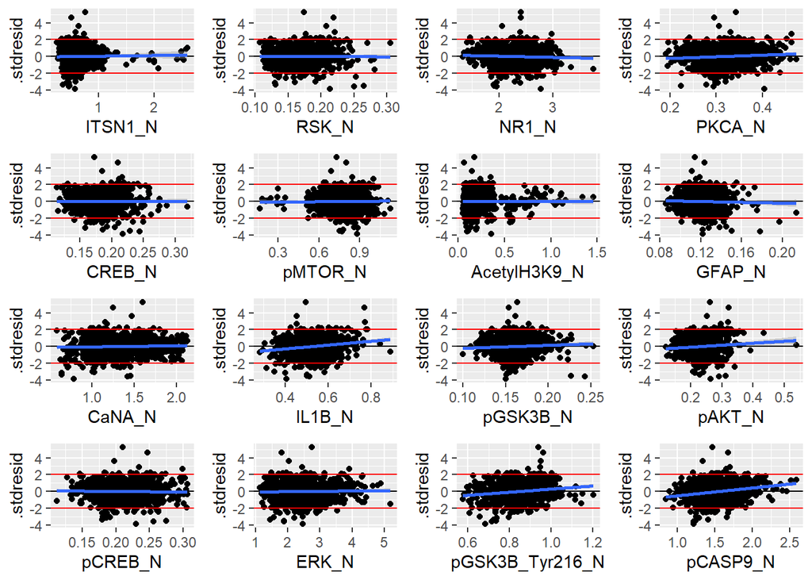

```r
mod_diag16 <- fortify(lm16)
gg_resid <- ggplot(data = lm16, aes(x = .fitted, y = .stdresid)) +
  geom_point() +
  geom_hline(yintercept = 0) +
  geom_smooth(method = "lm") +
  geom_hline(yintercept = 2, color = "red") +
  geom_hline(yintercept = -2, color = "red")

res_1 <- gg_resid + aes(x = sdata$ITSN1_N) + xlab('ITSN1_N')
res_2 <- gg_resid + aes(x = sdata$RSK_N) + xlab('RSK_N')
res_3 <- gg_resid + aes(x = sdata$NR1_N) + xlab('NR1_N')
res_4 <- gg_resid + aes(x = sdata$PKCA_N) + xlab('PKCA_N')
res_5 <- gg_resid + aes(x = sdata$CREB_N) + xlab('CREB_N')
res_6 <- gg_resid + aes(x = sdata$pMTOR_N) + xlab('pMTOR_N')
res_7 <- gg_resid + aes(x = sdata$AcetylH3K9_N) + xlab('AcetylH3K9_N')
res_8 <- gg_resid + aes(x = sdata$GFAP_N) + xlab('GFAP_N')
res_9 <- gg_resid + aes(x = sdata$CaNA_N) + xlab('CaNA_N')
res_10 <- gg_resid + aes(x = sdata$IL1B_N) + xlab('IL1B_N')
res_11 <- gg_resid + aes(x = sdata$pGSK3B_N) + xlab('pGSK3B_N')
res_12 <- gg_resid + aes(x = sdata$pAKT_N) + xlab('pAKT_N')
res_13 <- gg_resid + aes(x = sdata$pCREB_N) + xlab('pCREB_N')
res_14 <- gg_resid + aes(x = sdata$ERK_N) + xlab('ERK_N')
res_15 <- gg_resid + aes(x = sdata$pGSK3B_Tyr216_N) + xlab('pGSK3B_Tyr216_N')
res_16 <- gg_resid + aes(x = sdata$pCASP9_N) + xlab('pCASP9_N')


grid.arrange(res_1, res_2, res_3, res_4, res_5, res_6, res_7, res_8, res_9, res_10, res_11, res_12, res_13, res_14, res_15, res_16, nrow = 4)
```

We can see a correlation between dependence variable and IL1B_N, pAKT_N, pGSK3B_Tyr216_N, pCASP9_N. We should add this variables in the model.

Besides that, now that there are few predictors left, let’s look at the correlation matrix:

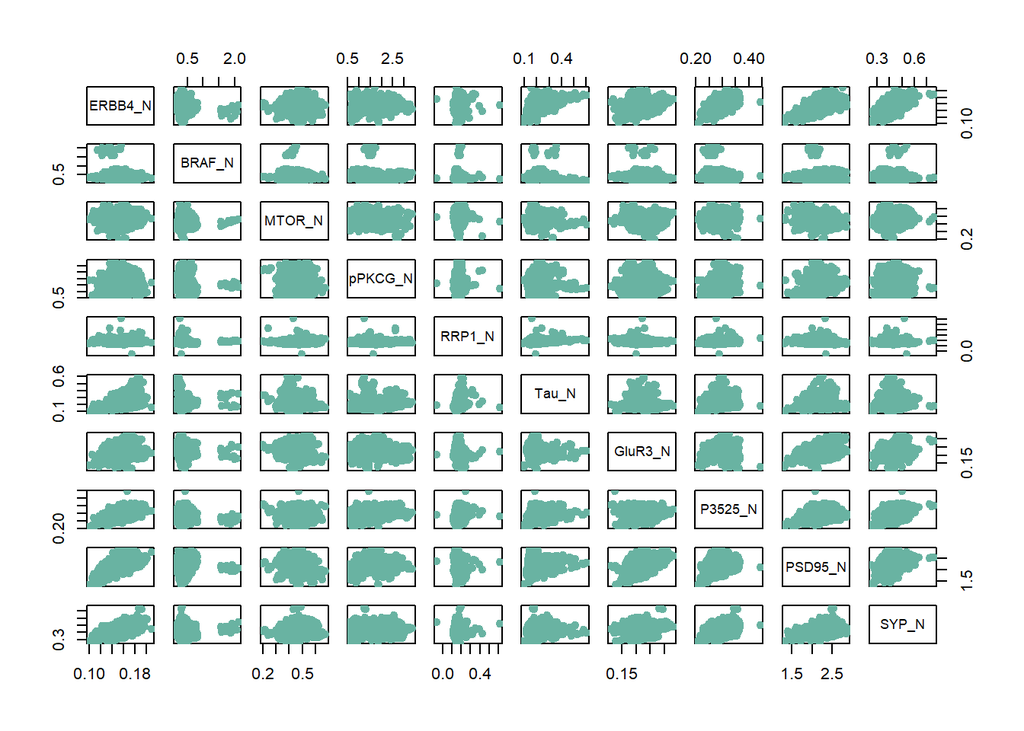

```r
prot <- select(sdata, ERBB4_N, BRAF_N, MTOR_N, pPKCG_N, RRP1_N, Tau_N,
    GluR3_N, P3525_N, PSD95_N, SYP_N)
plot(prot, pch=20 , cex=1.5 , col="#69b3a2")
```

```r
lm17 <- update(lm16, .~.-BRAF_N-RRP1_N+IL1B_N+pAKT_N+pGSK3B_Tyr216_N+pCASP9_N)
drop1(lm17)
```

```
## Single term deletions
##
## Model:
## ERBB4_N ~ MTOR_N + pPKCG_N + Tau_N + GluR3_N + P3525_N + PSD95_N +
##     SYP_N + IL1B_N + pAKT_N + pGSK3B_Tyr216_N + pCASP9_N
##                 Df Sum of Sq      RSS      AIC
## <none>                       0.060032 -10201.6
## MTOR_N           1 0.0030425 0.063075 -10151.8
## pPKCG_N          1 0.0034237 0.063456 -10145.5
## Tau_N            1 0.0140691 0.074101  -9983.1
## GluR3_N          1 0.0022844 0.062317 -10164.5
## P3525_N          1 0.0055474 0.065580 -10111.0
## PSD95_N          1 0.0116146 0.071647 -10018.4
## SYP_N            1 0.0024824 0.062515 -10161.2
## IL1B_N           1 0.0026495 0.062682 -10158.4
## pAKT_N           1 0.0001586 0.060191 -10200.8
## pGSK3B_Tyr216_N  1 0.0008520 0.060884 -10188.8
## pCASP9_N         1 0.0050089 0.065041 -10119.7
```

```r
summary(lm17)
```

```
##
## Call:
## lm(formula = ERBB4_N ~ MTOR_N + pPKCG_N + Tau_N + GluR3_N + P3525_N +
##     PSD95_N + SYP_N + IL1B_N + pAKT_N + pGSK3B_Tyr216_N + pCASP9_N,
##     data = sdata[, -c(1, 73:76)])
##
## Residuals:
##       Min        1Q    Median        3Q       Max
## -0.029996 -0.004457  0.000321  0.004779  0.040153
##
## Coefficients:
##                   Estimate Std. Error t value Pr(>|t|)
## (Intercept)      0.0132390  0.0036314   3.646 0.000280 ***
## MTOR_N           0.0347012  0.0047913   7.243 8.58e-13 ***
## pPKCG_N         -0.0042387  0.0005517  -7.683 3.60e-14 ***
## Tau_N            0.0594345  0.0038162  15.574  < 2e-16 ***
## GluR3_N         -0.0572909  0.0091289  -6.276 5.11e-10 ***
## P3525_N          0.1032737  0.0105601   9.780  < 2e-16 ***
## PSD95_N          0.0187084  0.0013221  14.151  < 2e-16 ***
## SYP_N            0.0312295  0.0047737   6.542 9.53e-11 ***
## IL1B_N           0.0276713  0.0040942   6.759 2.32e-11 ***
## pAKT_N           0.0140838  0.0085158   1.654 0.098461 .
## pGSK3B_Tyr216_N  0.0122569  0.0031980   3.833 0.000134 ***
## pCASP9_N         0.0133404  0.0014355   9.293  < 2e-16 ***
## ---
## Signif. codes:  0 '***' 0.001 '**' 0.01 '*' 0.05 '.' 0.1 ' ' 1
##
## Residual standard error: 0.007616 on 1035 degrees of freedom
## Multiple R-squared:  0.7513, Adjusted R-squared:  0.7487
## F-statistic: 284.3 on 11 and 1035 DF,  p-value: < 2.2e-16
```

Adjusted R-squared: 0.7487

## 3.3 Model Diagnostics

We can see that the residuals plot looks pretty good, as does Cook’s distance plot. This means that our dependence is linear, and there are no influential observations. The quantile graph looks worse.

#### Normality of distribution

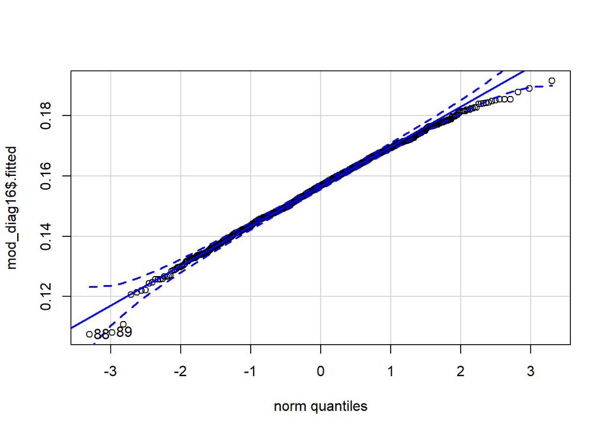

```
## [1] 88 89
```

```r
mod_diag17 <- fortify(lm17)
qqPlot(mod_diag16$.fitted)
```

#### Checking influential observations

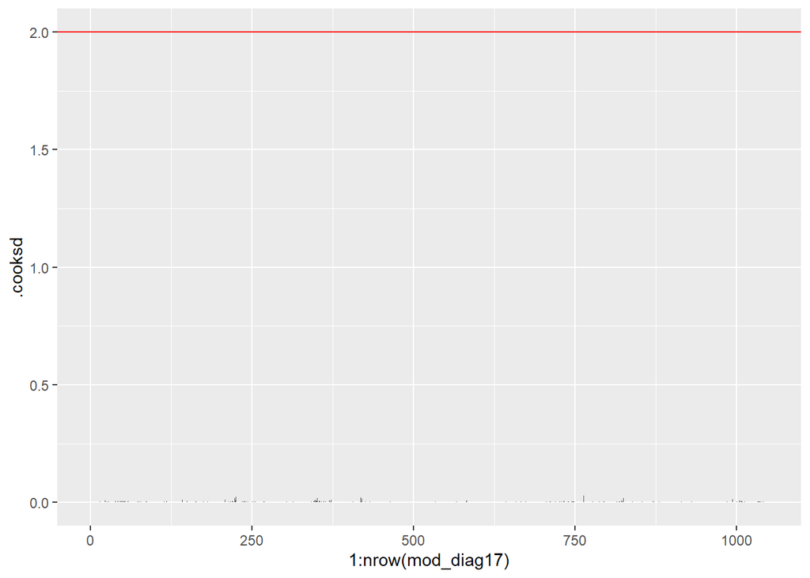

```r
ggplot(mod_diag17, aes(x = 1:nrow(mod_diag17), y = .cooksd)) +
  geom_bar(stat = "identity") +
  geom_hline(yintercept = 2, color = "red")
```

#### Checking the linearity of the corelation

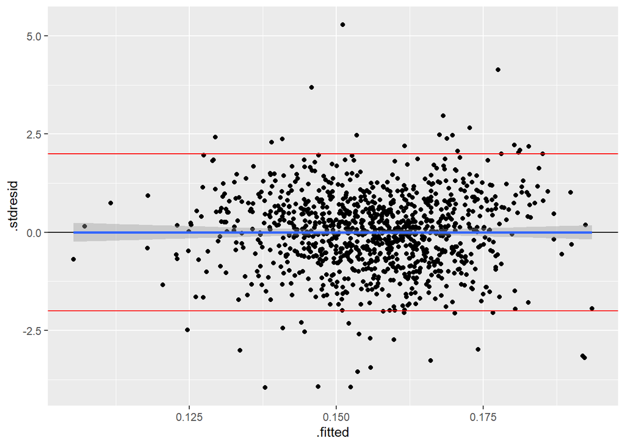

```r
ggplot(data = mod_diag17, aes(x = .fitted, y = .stdresid)) +
  geom_point() +
  geom_hline(yintercept = 0) +
  geom_smooth(method = "lm") +
  geom_hline(yintercept = 2, color = "red") +
  geom_hline(yintercept = -2, color = "red")
```

## 3.4 Prediction

Let’s build a graph of cost predictions from a variable that has the largest modulo coefficient (**P3525_N**)

```r
summary(lm17)
```

```
##
## Call:
## lm(formula = ERBB4_N ~ MTOR_N + pPKCG_N + Tau_N + GluR3_N + P3525_N +
##     PSD95_N + SYP_N + IL1B_N + pAKT_N + pGSK3B_Tyr216_N + pCASP9_N,
##     data = sdata[, -c(1, 73:76)])
##
## Residuals:
##       Min        1Q    Median        3Q       Max
## -0.029996 -0.004457  0.000321  0.004779  0.040153
##
## Coefficients:
##                   Estimate Std. Error t value Pr(>|t|)
## (Intercept)      0.0132390  0.0036314   3.646 0.000280 ***
## MTOR_N           0.0347012  0.0047913   7.243 8.58e-13 ***
## pPKCG_N         -0.0042387  0.0005517  -7.683 3.60e-14 ***
## Tau_N            0.0594345  0.0038162  15.574  < 2e-16 ***
## GluR3_N         -0.0572909  0.0091289  -6.276 5.11e-10 ***
## P3525_N          0.1032737  0.0105601   9.780  < 2e-16 ***
## PSD95_N          0.0187084  0.0013221  14.151  < 2e-16 ***
## SYP_N            0.0312295  0.0047737   6.542 9.53e-11 ***
## IL1B_N           0.0276713  0.0040942   6.759 2.32e-11 ***
## pAKT_N           0.0140838  0.0085158   1.654 0.098461 .
## pGSK3B_Tyr216_N  0.0122569  0.0031980   3.833 0.000134 ***
## pCASP9_N         0.0133404  0.0014355   9.293  < 2e-16 ***
## ---
## Signif. codes:  0 '***' 0.001 '**' 0.01 '*' 0.05 '.' 0.1 ' ' 1
##
## Residual standard error: 0.007616 on 1035 degrees of freedom
## Multiple R-squared:  0.7513, Adjusted R-squared:  0.7487
## F-statistic: 284.3 on 11 and 1035 DF,  p-value: < 2.2e-16
```

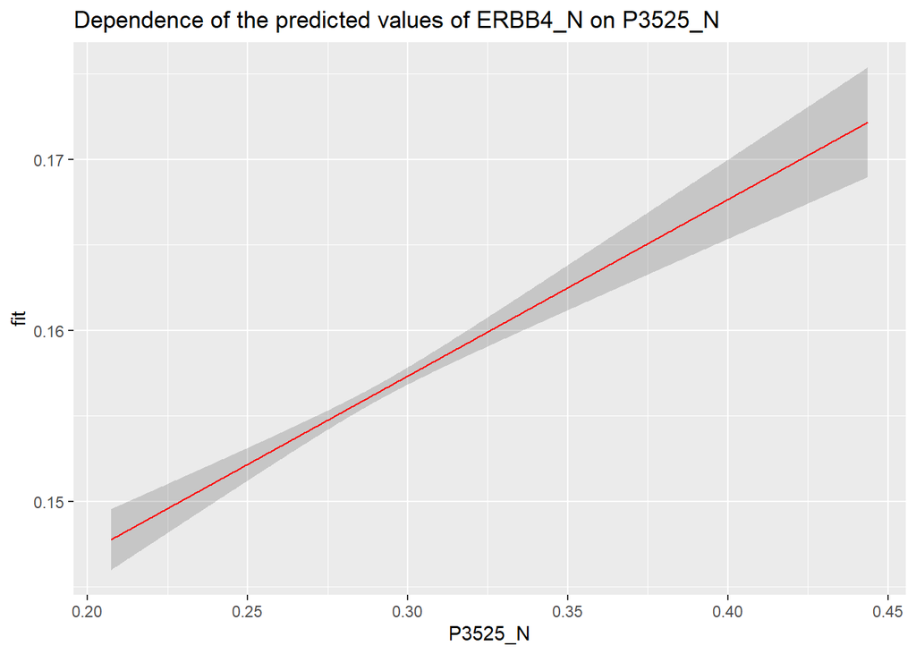

```r
#dataset with predictors
var_data <- data.frame(MTOR_N = mean(sdata$MTOR_N),
                       pPKCG_N = mean(sdata$pPKCG_N),
                       Tau_N = mean(sdata$Tau_N),
                       GluR3_N = mean(sdata$GluR3_N),
                       PSD95_N = mean(sdata$PSD95_N),
                       SYP_N = mean(sdata$SYP_N),
                       IL1B_N = mean(sdata$IL1B_N),
                       pAKT_N = mean(sdata$pAKT_N),
                       pGSK3B_Tyr216_N = mean(sdata$pGSK3B_Tyr216_N),
                       pCASP9_N = mean(sdata$pCASP9_N),
                       P3525_N = seq(min(sdata$P3525_N), max(sdata$P3525_N), length.out = 1047))

#predicted values
Predictions <- predict(lm17, newdata = var_data,  interval = 'confidence')
pred_data <- data.frame(var_data, Predictions)

#Model prediction plot
ggplot(pred_data, aes(x = P3525_N, y = fit)) +
  geom_ribbon(alpha = 0.2, aes(ymin = lwr, ymax = upr)) +
  geom_line(col = 'red') +
  ggtitle("Dependence of the predicted values of ERBB4_N on P3525_N")
```

# 4. PCA

### 4.1 Principal components

```r
pca <- rda(sdata[, -c(1, 73:76)], scale = TRUE)
head(summary(pca))
```

```
##
## Call:
## rda(X = sdata[, -c(1, 73:76)], scale = TRUE)
##
## Partitioning of correlations:
##               Inertia Proportion
## Total              71          1
## Unconstrained      71          1
##
## Eigenvalues, and their contribution to the correlations
##
## Importance of components:
##                           PC1     PC2    PC3     PC4     PC5     PC6     PC7
## Eigenvalue            19.8054 11.6089 7.8992 5.47087 3.47082 3.32800 2.42530
## Proportion Explained   0.2789  0.1635 0.1113 0.07705 0.04888 0.04687 0.03416
## Cumulative Proportion  0.2789  0.4425 0.5537 0.63077 0.67965 0.72652 0.76068
##                           PC8     PC9    PC10    PC11    PC12    PC13    PC14
## Eigenvalue            2.11999 1.64761 1.23325 1.03041 0.88974 0.72959 0.71480
## Proportion Explained  0.02986 0.02321 0.01737 0.01451 0.01253 0.01028 0.01007
## Cumulative Proportion 0.79054 0.81375 0.83112 0.84563 0.85816 0.86844 0.87851
##                           PC15     PC16     PC17     PC18     PC19     PC20
## Eigenvalue            0.632448 0.566450 0.495026 0.466214 0.418109 0.409061
## Proportion Explained  0.008908 0.007978 0.006972 0.006566 0.005889 0.005761
## Cumulative Proportion 0.887413 0.895391 0.902364 0.908930 0.914819 0.920580
##                           PC21     PC22     PC23     PC24     PC25     PC26
## Eigenvalue            0.377229 0.363159 0.318979 0.298263 0.286756 0.262330
## Proportion Explained  0.005313 0.005115 0.004493 0.004201 0.004039 0.003695
## Cumulative Proportion 0.925893 0.931008 0.935501 0.939702 0.943741 0.947435
##                           PC27     PC28     PC29     PC30     PC31     PC32
## Eigenvalue            0.239107 0.222887 0.201093 0.186395 0.176681 0.170436
## Proportion Explained  0.003368 0.003139 0.002832 0.002625 0.002488 0.002401
## Cumulative Proportion 0.950803 0.953942 0.956775 0.959400 0.961889 0.964289
##                           PC33     PC34     PC35    PC36     PC37    PC38
## Eigenvalue            0.166947 0.144776 0.140389 0.12712 0.121579 0.11784
## Proportion Explained  0.002351 0.002039 0.001977 0.00179 0.001712 0.00166
## Cumulative Proportion 0.966640 0.968679 0.970657 0.97245 0.974160 0.97582
##                           PC39     PC40     PC41     PC42     PC43     PC44
## Eigenvalue            0.112958 0.109802 0.107146 0.100056 0.088423 0.085107
## Proportion Explained  0.001591 0.001547 0.001509 0.001409 0.001245 0.001199
## Cumulative Proportion 0.977410 0.978957 0.980466 0.981875 0.983121 0.984319
```

[output cut: 34 more lines]

```
## NR2A_N   -1.5422  0.6507  0.2194  0.70551  0.14142 -0.13723
## pAKT_N   -1.0971 -1.0167 -0.5765 -0.74689  0.18434  0.33157
## ....
##
##
## Site scores (weighted sums of species scores)
##
##           PC1    PC2     PC3     PC4    PC5     PC6
## sit1 -0.49591 0.7272 -0.3314 0.48980 0.3716 -0.3162
## sit2 -0.30856 0.7227 -0.1632 0.35697 0.2799 -0.2297
## sit3 -0.32128 0.7581 -0.1158 0.28152 0.2936 -0.1761
## sit4 -0.05234 0.5275 -0.4865 0.17245 0.4144 -0.2435
## sit5  0.07211 0.5572 -0.2687 0.07571 0.3629 -0.1793
## sit6  0.07303 0.5844 -0.3085 0.08435 0.4639 -0.1271
## ....
```

### 4.2 Eigenvectors graph, correlation biplot

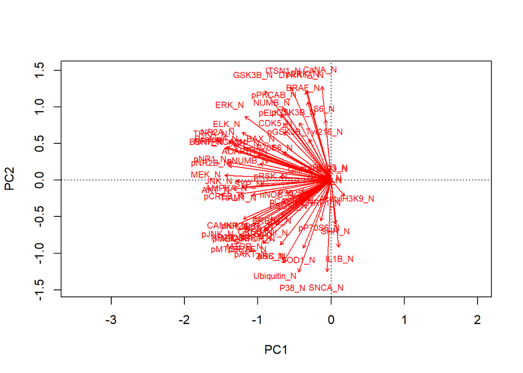

```r
biplot(pca, scaling = "species", display = "species")
```

### 4.3 Ordination plot

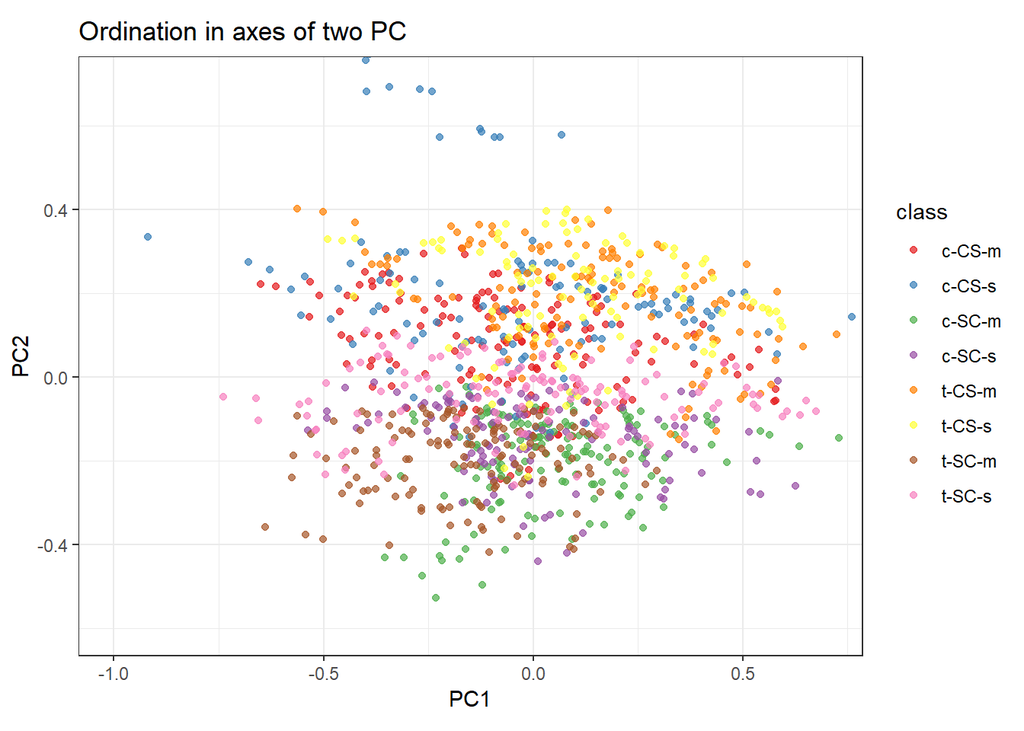

[interactive chart not shown]

```r
df_scores <- data.frame(sdata[, -c(1, 73:75)],
                        scores(pca, display = "sites", choices = c(1, 2, 3), scaling = "sites"))

mycolors <- brewer.pal(8, "Set1")
df_scores$color <- mycolors[ as.numeric(df_scores$class)]


plot3d(
  x = df_scores$PC1, y = df_scores$PC2, z = df_scores$PC3,
  col = df_scores$color,
  type = 's',
  radius = .015,
  alpha = 0.7,
  xlab="PC1", ylab="PC2", zlab="PC3",
  main = 'Ordination in axes of three PC'
)


ggplot(df_scores, aes(x = PC1, y = PC2)) +
  geom_point(aes(color = class), alpha = 0.7) +
  coord_equal(xlim = c(-1, 0.7), ylim = c(-0.6, 0.7)) +
  scale_color_brewer(palette = 'Set1') +
 ggtitle(label = "Ordination in axes of two PC") + theme_bw()
```

### 4.4 Interpretation

#### 4.4.1 Number of PC

Let’s look at eigenvalues and eigenvalues plot:

```r
eigenvals(pca)
```

```
##       PC1       PC2       PC3       PC4       PC5       PC6       PC7       PC8
## 19.805416 11.608917  7.899171  5.470870  3.470825  3.327997  2.425302  2.119994
##       PC9      PC10      PC11      PC12      PC13      PC14      PC15      PC16
##  1.647612  1.233249  1.030408  0.889744  0.729590  0.714804  0.632448  0.566450
##      PC17      PC18      PC19      PC20      PC21      PC22      PC23      PC24
##  0.495026  0.466214  0.418109  0.409061  0.377229  0.363159  0.318979  0.298263
##      PC25      PC26      PC27      PC28      PC29      PC30      PC31      PC32
##  0.286756  0.262330  0.239107  0.222887  0.201093  0.186395  0.176681  0.170436
##      PC33      PC34      PC35      PC36      PC37      PC38      PC39      PC40
##  0.166947  0.144776  0.140389  0.127121  0.121579  0.117839  0.112958  0.109802
##      PC41      PC42      PC43      PC44      PC45      PC46      PC47      PC48
##  0.107146  0.100056  0.088423  0.085107  0.083058  0.079279  0.074870  0.071351
##      PC49      PC50      PC51      PC52      PC53      PC54      PC55      PC56
##  0.066829  0.061471  0.060016  0.055909  0.051821  0.048855  0.046581  0.044288
##      PC57      PC58      PC59      PC60      PC61      PC62      PC63      PC64
##  0.042561  0.039768  0.036886  0.035774  0.033965  0.029325  0.025828  0.025375
##      PC65      PC66      PC67      PC68      PC69      PC70
##  0.024462  0.018854  0.015948  0.015244  0.014356  0.010662
```

```r
bstick(pca)
```

```
##        PC1        PC2        PC3        PC4        PC5        PC6        PC7
## 4.90187728 3.88759157 3.38044871 3.04235347 2.78878204 2.58592490 2.41687728
##        PC8        PC9       PC10       PC11       PC12       PC13       PC14
## 2.27197932 2.14519361 2.03249520 1.93106663 1.83885883 1.75433502 1.67631305
##       PC15       PC16       PC17       PC18       PC19       PC20       PC21
## 1.60386407 1.53624502 1.47285216 1.41318830 1.35683909 1.30345563 1.25274134
##       PC22       PC23       PC24       PC25       PC26       PC27       PC28
## 1.20444203 1.15833813 1.11423875 1.07197685 1.03140542 0.99239443 0.95482829
##       PC29       PC30       PC31       PC32       PC33       PC34       PC35
## 0.91860380 0.88362843 0.84981891 0.81710001 0.78540358 0.75466765 0.72483572
##       PC36       PC37       PC38       PC39       PC40       PC41       PC42
## 0.69585613 0.66768153 0.64026840 0.61357667 0.58756934 0.56221220 0.53747352
##       PC43       PC44       PC45       PC46       PC47       PC48       PC49
## 0.51332386 0.48973582 0.46668388 0.44414419 0.42209450 0.40051396 0.37938301
##       PC50       PC51       PC52       PC53       PC54       PC55       PC56
## 0.35868330 0.33839758 0.31850963 0.29900413 0.27986667 0.26108360 0.24264204
##       PC57       PC58       PC59       PC60       PC61       PC62       PC63
## 0.22452979 0.20673531 0.18924762 0.17205634 0.15515158 0.13852394 0.12216450
##       PC64       PC65       PC66       PC67       PC68       PC69       PC70
## 0.10606472 0.09021651 0.07461211 0.05924415 0.04410556 0.02918959 0.01448980
```

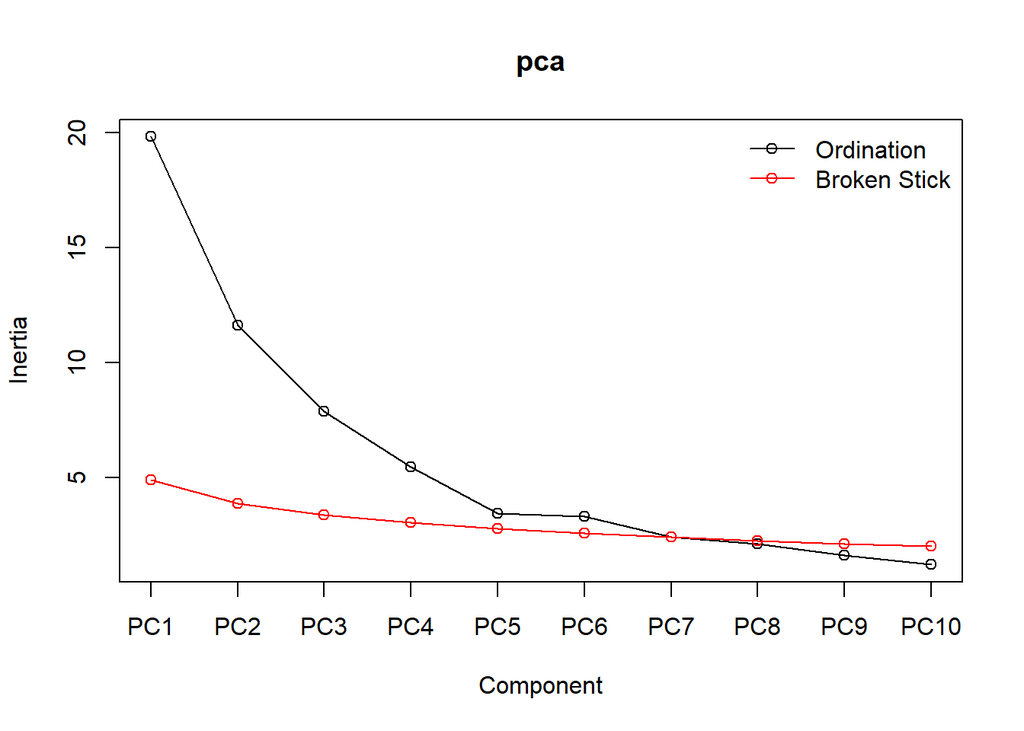

```r
screeplot(pca, type = "lines", bstick = TRUE)
```

Let’s see how each component contributes to the overall variability:

```r
head(summary(pca))
```

```
##
## Call:
## rda(X = sdata[, -c(1, 73:76)], scale = TRUE)
##
## Partitioning of correlations:
##               Inertia Proportion
## Total              71          1
## Unconstrained      71          1
##
## Eigenvalues, and their contribution to the correlations
##
## Importance of components:
##                           PC1     PC2    PC3     PC4     PC5     PC6     PC7
## Eigenvalue            19.8054 11.6089 7.8992 5.47087 3.47082 3.32800 2.42530
## Proportion Explained   0.2789  0.1635 0.1113 0.07705 0.04888 0.04687 0.03416
## Cumulative Proportion  0.2789  0.4425 0.5537 0.63077 0.67965 0.72652 0.76068
##                           PC8     PC9    PC10    PC11    PC12    PC13    PC14
## Eigenvalue            2.11999 1.64761 1.23325 1.03041 0.88974 0.72959 0.71480
## Proportion Explained  0.02986 0.02321 0.01737 0.01451 0.01253 0.01028 0.01007
## Cumulative Proportion 0.79054 0.81375 0.83112 0.84563 0.85816 0.86844 0.87851
##                           PC15     PC16     PC17     PC18     PC19     PC20
## Eigenvalue            0.632448 0.566450 0.495026 0.466214 0.418109 0.409061
## Proportion Explained  0.008908 0.007978 0.006972 0.006566 0.005889 0.005761
## Cumulative Proportion 0.887413 0.895391 0.902364 0.908930 0.914819 0.920580
##                           PC21     PC22     PC23     PC24     PC25     PC26
## Eigenvalue            0.377229 0.363159 0.318979 0.298263 0.286756 0.262330
## Proportion Explained  0.005313 0.005115 0.004493 0.004201 0.004039 0.003695
## Cumulative Proportion 0.925893 0.931008 0.935501 0.939702 0.943741 0.947435
##                           PC27     PC28     PC29     PC30     PC31     PC32
## Eigenvalue            0.239107 0.222887 0.201093 0.186395 0.176681 0.170436
## Proportion Explained  0.003368 0.003139 0.002832 0.002625 0.002488 0.002401
## Cumulative Proportion 0.950803 0.953942 0.956775 0.959400 0.961889 0.964289
##                           PC33     PC34     PC35    PC36     PC37    PC38
## Eigenvalue            0.166947 0.144776 0.140389 0.12712 0.121579 0.11784
## Proportion Explained  0.002351 0.002039 0.001977 0.00179 0.001712 0.00166
## Cumulative Proportion 0.966640 0.968679 0.970657 0.97245 0.974160 0.97582
##                           PC39     PC40     PC41     PC42     PC43     PC44
## Eigenvalue            0.112958 0.109802 0.107146 0.100056 0.088423 0.085107
## Proportion Explained  0.001591 0.001547 0.001509 0.001409 0.001245 0.001199
## Cumulative Proportion 0.977410 0.978957 0.980466 0.981875 0.983121 0.984319
```

[output cut: 34 more lines]

```
## NR2A_N   -1.5422  0.6507  0.2194  0.70551  0.14142 -0.13723
## pAKT_N   -1.0971 -1.0167 -0.5765 -0.74689  0.18434  0.33157
## ....
##
##
## Site scores (weighted sums of species scores)
##
##           PC1    PC2     PC3     PC4    PC5     PC6
## sit1 -0.49591 0.7272 -0.3314 0.48980 0.3716 -0.3162
## sit2 -0.30856 0.7227 -0.1632 0.35697 0.2799 -0.2297
## sit3 -0.32128 0.7581 -0.1158 0.28152 0.2936 -0.1761
## sit4 -0.05234 0.5275 -0.4865 0.17245 0.4144 -0.2435
## sit5  0.07211 0.5572 -0.2687 0.07571 0.3629 -0.1793
## sit6  0.07303 0.5844 -0.3085 0.08435 0.4639 -0.1271
## ....
```

```r
pca_summary <- summary(pca)
pca_result <- as.data.frame(pca_summary$cont)
plot_data <- as.data.frame(t(pca_result[c("Proportion Explained"),]))
plot_data$component <- str_remove(rownames(plot_data), pattern = 'importance.')
str(plot_data)
```

```
## 'data.frame':    70 obs. of  2 variables:
##  $ Proportion Explained: num  0.2789 0.1635 0.1113 0.0771 0.0489 ...
##  $ component           : chr  "PC1" "PC2" "PC3" "PC4" ...
```

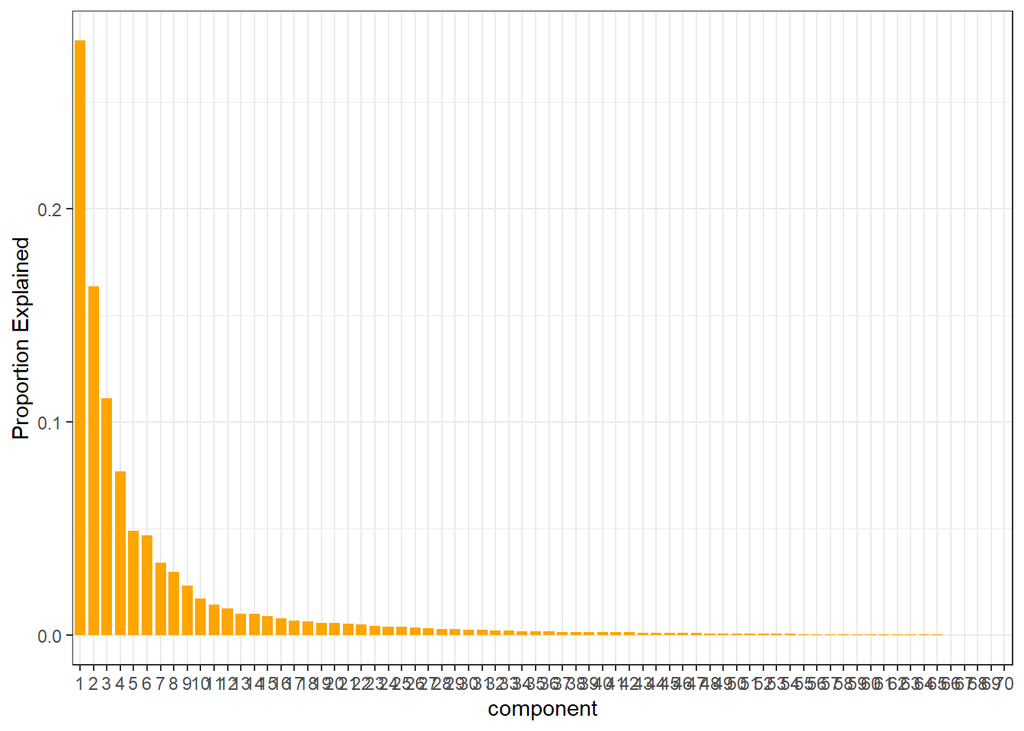

```r
plot_data %>%
  arrange(desc(`Proportion Explained`)) %>%
  mutate(component=factor(component, levels=component)) %>%
  ggplot(aes(x=component, y=`Proportion Explained`)) +
    geom_bar(stat = "identity", fill = 'orange', width=0.8) +
    theme_bw() +
    scale_x_discrete(breaks = plot_data$component,
                          labels = labels)
```

To interpret the components, we will take the first seven components, they explain 76% of the total variability (it’s more than by Broken Stick Model), their main numbers are greater than 1.

#### 4.4.2 Component interpretation

```r
scores(pca, display = "species", choices = 1:7, scaling = 0)
```

```
##                          PC1           PC2          PC3          PC4
## DYRK1A_N        -0.046574758  0.2147377482 -0.089748098  0.018738290
## ITSN1_N         -0.074671162  0.2235870427 -0.054586112  0.005451313
## BDNF_N          -0.195455201  0.0780863437 -0.059779443  0.005581125
## NR1_N           -0.192777120  0.0794583962  0.048868092  0.076370016
## NR2A_N          -0.176883951  0.0974779717  0.039850156  0.153960614
## pAKT_N          -0.125828430 -0.1523120763 -0.104691979 -0.162990473
## pBRAF_N         -0.131107895 -0.1420799101 -0.126787136 -0.127524554
## pCAMKII_N       -0.102608440 -0.1081829193  0.028774044 -0.049966998
## pCREB_N         -0.167862734 -0.0337657622  0.015232692 -0.144703071
## pELK_N          -0.088120332  0.1370683538 -0.116811121  0.077528766
## pERK_N          -0.044859888  0.2168289642 -0.081568991  0.035560651
## pJNK_N          -0.177423911 -0.1104381132 -0.022336297 -0.065458161
## PKCA_N          -0.160810344  0.0778951899 -0.089957514 -0.101024873
## pMEK_N          -0.158087704 -0.1204132122 -0.090404426 -0.145285617
## pNR1_N          -0.189066728  0.0431208012  0.053657127  0.130758957
## pNR2A_N         -0.141675373 -0.0939756978  0.117569827  0.099104478
## pNR2B_N         -0.188800244  0.0348089059  0.084109333  0.137003523
## pPKCAB_N        -0.089546451  0.1741825847 -0.064386059 -0.128342608
## pRSK_N          -0.095030793  0.0078649459 -0.079696237 -0.266618653
## AKT_N           -0.180651697 -0.0210937786  0.051761320  0.101056683
## BRAF_N          -0.043869628  0.1884284327 -0.121690287 -0.021236770
## CAMKII_N        -0.162031436 -0.0929380228 -0.117646108 -0.063877584
## CREB_N          -0.118490775 -0.1061417896 -0.146916861 -0.173849580
## ELK_N           -0.163707227  0.1143279471  0.102482219  0.082204325
## ERK_N           -0.159040376  0.1536228027  0.071112584  0.103981162
## GSK3B_N         -0.122324750  0.2144628005 -0.051140844 -0.005847817
## JNK_N           -0.175864195 -0.0028398283 -0.116789645 -0.131378912
## MEK_N           -0.196196610  0.0111699497 -0.027625053 -0.094648593
## TRKA_N          -0.189117856  0.0945158976  0.037618141 -0.063533784
## RSK_N           -0.112705218 -0.0958314490 -0.147350019 -0.181921694
## APP_N           -0.134164360  0.0742737365 -0.070114393 -0.037255844
## Bcatenin_N      -0.179731192  0.0839748244  0.081990654  0.075357184
## SOD1_N          -0.051571377 -0.1638504317  0.086430946  0.026716221
## MTOR_N          -0.135837555 -0.1359504076 -0.102891728  0.142625702
## P38_N           -0.060320249 -0.2210945799 -0.063594095  0.109482405
## pMTOR_N         -0.155984871 -0.1415033722 -0.026310482  0.131434538
## DSCR1_N         -0.123679518 -0.1185129071 -0.157498024  0.076282801
## AMPKA_N         -0.163991392 -0.0165002838 -0.106935142  0.194423770
## NR2B_N          -0.161552387 -0.1176704163 -0.072450545  0.106472505
```

[output cut: 91 more lines]

```
## GluR3_N          0.025060748 -0.0003900241  1.474633e-01
## GluR4_N         -0.048818001 -0.1152748189  6.475461e-02
## IL1B_N          -0.114574085  0.1666151523 -1.787670e-02
## P3525_N         -0.196760562 -0.0940171792  5.297181e-02
## pCASP9_N        -0.024796678  0.0053961699  1.595808e-01
## PSD95_N          0.100263418  0.1651000626 -1.707899e-02
## SNCA_N          -0.213248280  0.1134991751  2.019192e-02
## Ubiquitin_N      0.010714961  0.0495780910  3.016108e-02
## pGSK3B_Tyr216_N  0.042016945  0.1238902725  3.575267e-02
## SHH_N           -0.117099582  0.0895712784 -2.336466e-02
## pS6_N           -0.080787945  0.0733347373 -7.345049e-02
## SYP_N           -0.053873729  0.0647327355  2.160515e-01
## CaNA_N          -0.051100026  0.0894756449  1.842864e-01
## attr(,"const")
## [1] 16.50812
```